# Telecomunication EDA

Nzambuli Daniel

2023-11-09

# Task

Perform Exploratory data analysis

1. data preparation
   - data with missing observations
   - explore
   - selecting the variables
2. assumptions for linear regression
   - normality
   - linearity
   - homoscedasticity
   - multi-colinearity
3. linear regression analysis - `continuous`
   - handling anomalies
4. GLMs
   - logostic regression - uses data that is `binomial`, `multinomial`, `ordinal`
   - poisson regression - `count data`
   - negative binomial
   - quasi binomial
5. Non Parametric tests
   - sign rank test = `one-sample t-test, one-sample z-test`
   - wilcoxcon sign rank test = `paired t-test`
   - mann u test = `independent t-test`
   - Kruskal-wallis H-test = `one way ANOVA`
   - Pearson Correlation = `spearman rank correlation`
6. Handling correlated data/ multivariate data
7. Exploratory
   1. PCA, Factor Analysis
   2. Fixed effect and random effect models
   3. handling missing data
   4. assessing missingness types:
      - MAR
      - CMAR
      - MNAR
      - GEE regression

## 1. The Data Set

```r
library(readxl)
Telecommunication_Data <- read_excel("Telecommunication Data.xlsx")
View(Telecommunication_Data)
```

**See the data inline**

```r
head(Telecommunication_Data)
```

```
## # A tibble: 6 × 22
##   region tenure   age marital   address income employ retire gender reside
##   <chr>   <dbl> <dbl> <chr>       <dbl>  <dbl>  <dbl> <chr>  <chr>   <dbl>
## 1 Zone 2     13    44 Married         9     64      5 No     Male        2
## 2 <NA>       11    33 Married         7    136      5 No     Male        6
## 3 Zone 3     68    52 Married        24     NA     29 No     Female      2
## 4 Zone 2     33    33 Unmarried      12     33      0 No     Female     NA
## 5 Zone 2     23    30 Married         9     30      2 No     Male        4
## 6 Zone 2     41    39 Unmarried      17     78     16 No     Female      1
## # ℹ 12 more variables: tollfree <chr>, tollten <dbl>, equipten <dbl>,
## #   cardten <dbl>, wireten <dbl>, loglong <dbl>, logtoll <dbl>, logequi <dbl>,
## #   logcard <dbl>, logwire <dbl>, custcat <chr>, churn <chr>
```

### Data Exploration

**Column names of the data**

```r
colnames(Telecommunication_Data)
```

```
##  [1] "region"   "tenure"   "age"      "marital"  "address"  "income"
##  [7] "employ"   "retire"   "gender"   "reside"   "tollfree" "tollten"
## [13] "equipten" "cardten"  "wireten"  "loglong"  "logtoll"  "logequi"
## [19] "logcard"  "logwire"  "custcat"  "churn"
```

## 2 Data Preparation

**Finding the missing values in each column**

```r
missing_values = data.frame(columns = colnames(Telecommunication_Data),
                            vals_missing = colSums(is.na(Telecommunication_Data)),
                            perc_missing = colMeans(is.na(Telecommunication_Data)) * 100)

head(missing_values)
```

```
##         columns vals_missing perc_missing
## region   region            7          0.7
## tenure   tenure            8          0.8
## age         age            5          0.5
## marital marital            9          0.9
## address address            8          0.8
## income   income            8          0.8
```

### Dealing with extreme missing values

```r
# columns with more than 50% missing values need to be removed
Telecommunication_Data = Telecommunication_Data[rowMeans(is.na(Telecommunication_Data))< 0.5, colMeans(is.na(Telecommunication_Data)) < 0.5]
colnames(Telecommunication_Data)
```

```
##  [1] "region"   "tenure"   "age"      "marital"  "address"  "income"
##  [7] "employ"   "retire"   "gender"   "reside"   "tollfree" "tollten"
## [13] "equipten" "cardten"  "wireten"  "loglong"  "logcard"  "custcat"
## [19] "churn"
```

### Split the data into Train and Test

```r
set.seed(123)

# split witha 70/30 ration
ind = sample(1:nrow(Telecommunication_Data), 0.7 * nrow(Telecommunication_Data))

train = Telecommunication_Data[ind,]
test = Telecommunication_Data[-ind,]

nrow(train)
```

```
## [1] 700
```

```r
nrow(test)
```

```
## [1] 300
```

## 3. Select The Variables

### Linear Regression

```r
linear_regress_data = train
```

#### Na values in Str columns

```r
library(dplyr, warn.conflicts = FALSE)

char_columns = colnames(linear_regress_data %>% select_if(is.character))
char_columns
```

```
## [1] "region"   "marital"  "retire"   "gender"   "tollfree" "custcat"  "churn"
```

#### Spread in the character columns

```r
library(ggplot2)
plot_distrib = function(col_name){
  # convert the data into columns
  col_vals = data.frame(table(col_name))
  col_vals$percent = col_vals$Freq / sum(col_vals$Freq) * 100
  # plot the distibution
  plot = ggplot(col_vals, aes(x = "", y = Freq, fill = as.factor(as.character(col_name)))) +
    geom_bar(stat = "identity") +
    coord_polar("y") +
    geom_text(aes(label = paste0(round(percent), "%")), position = position_stack(vjust = 0.5)) +
    ggtitle("Distribution Percentages") +
    theme_light()
  return(plot)
}
```

```r
char_columns
```

```
## [1] "region"   "marital"  "retire"   "gender"   "tollfree" "custcat"  "churn"
```

```r
print("Distribution of Region")
```

```
## [1] "Distribution of Region"
```

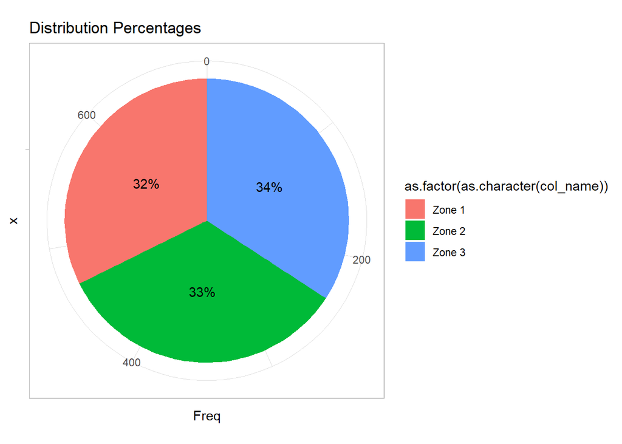

```r
img = plot_distrib(linear_regress_data$region)
print(img)
```

```r
print("Distribution of Marital")
```

```
## [1] "Distribution of Marital"
```

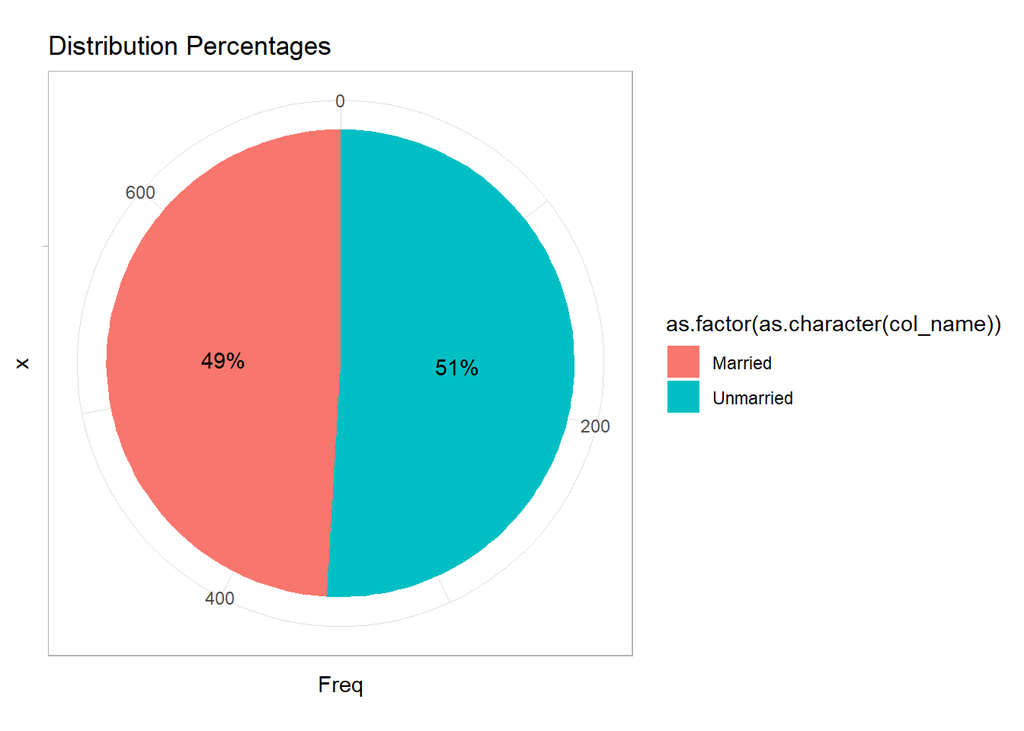

```r
img = plot_distrib(linear_regress_data$marital)
print(img)
```

```r
print("Distribution of Retire")
```

```
## [1] "Distribution of Retire"
```

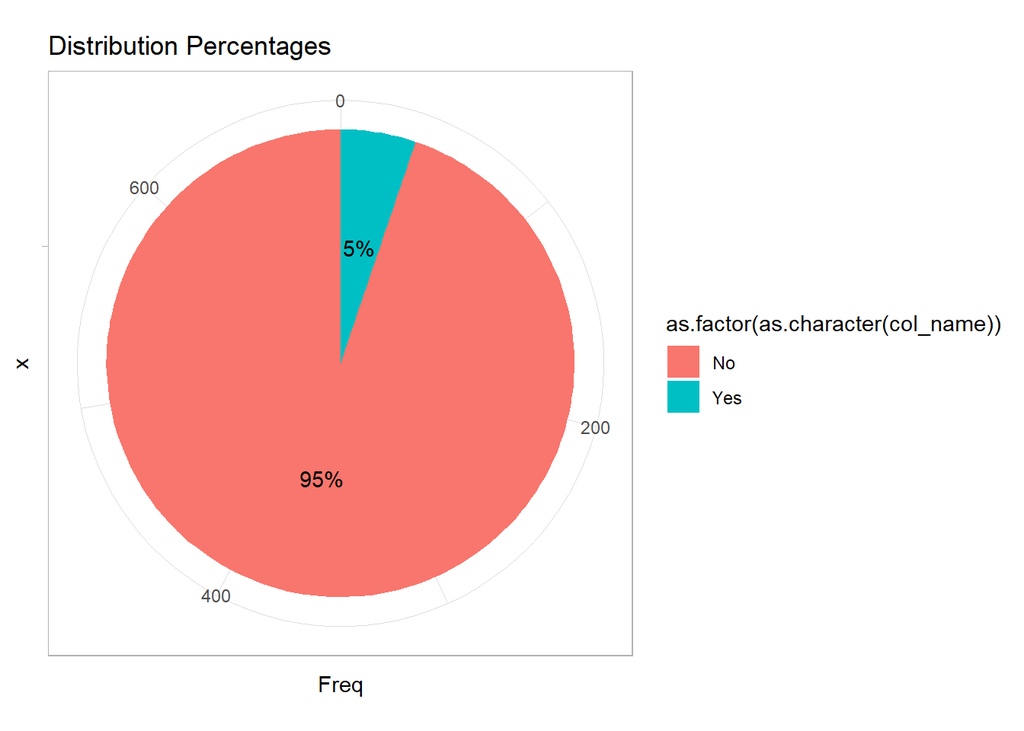

```r
img = plot_distrib(linear_regress_data$retire)
print(img)
```

```r
print("Distribution of Gender")
```

```
## [1] "Distribution of Gender"
```

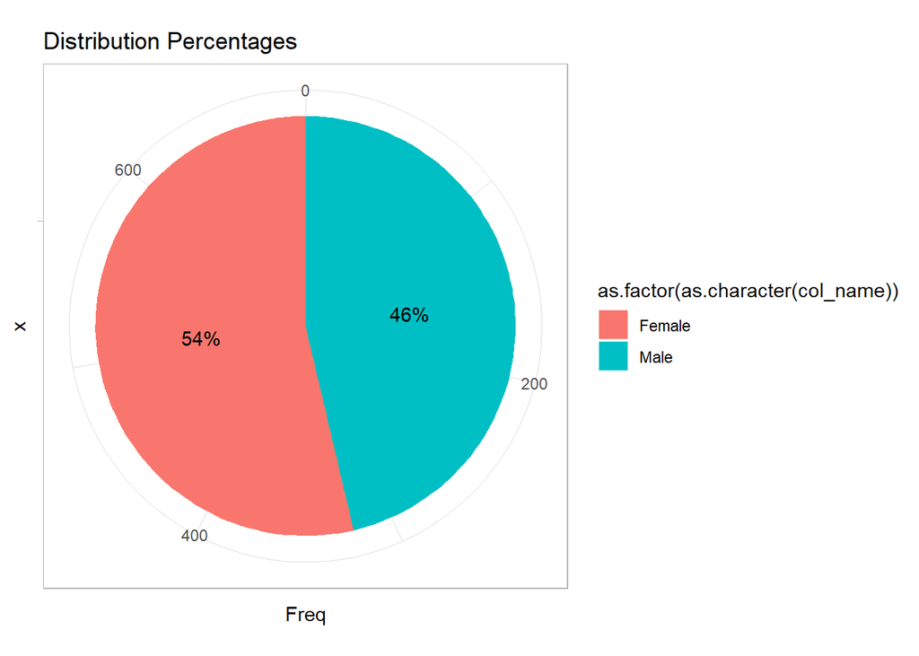

```r
img = plot_distrib(linear_regress_data$gender)
print(img)
```

```r
print("Distribution of TollFree")
```

```
## [1] "Distribution of TollFree"
```

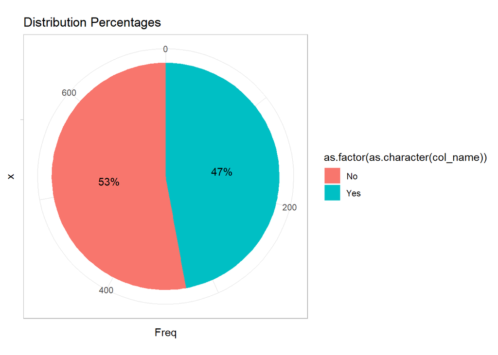

```r
img = plot_distrib(linear_regress_data$tollfree)
print(img)
```

```r
print("Distribution of Custcat")
```

```
## [1] "Distribution of Custcat"
```

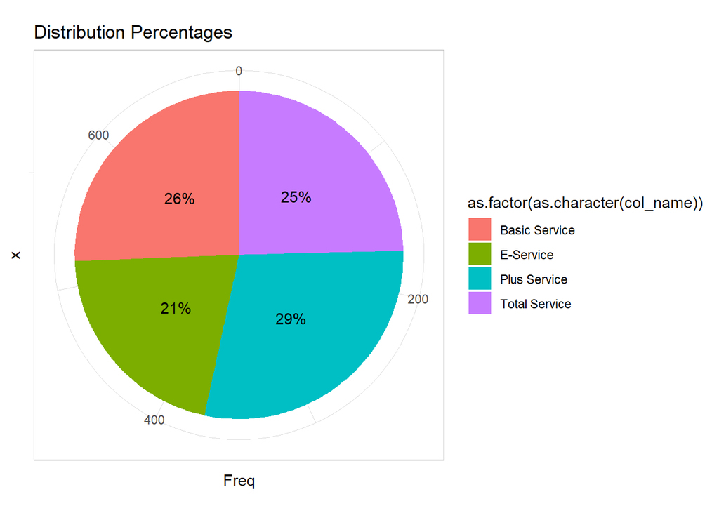

```r
img = plot_distrib(linear_regress_data$custcat)
print(img)
```

```r
print("Distribution of Churn")
```

```
## [1] "Distribution of Churn"
```

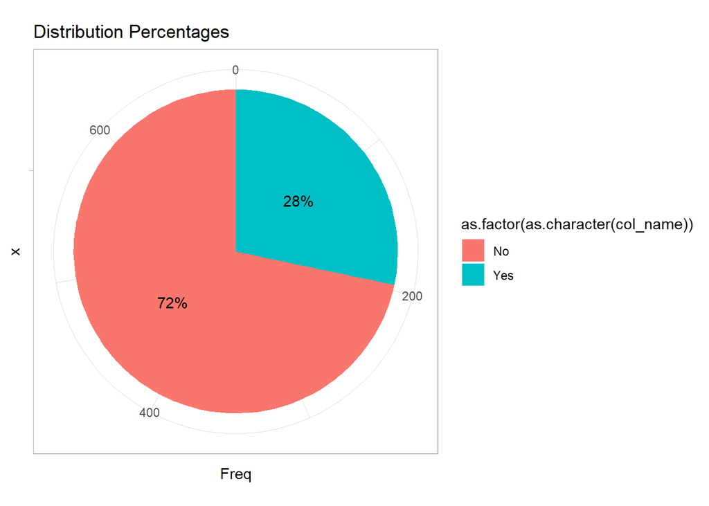

```r
img = plot_distrib(linear_regress_data$churn)
print(img)
```

#### Impute the Non-numeric Columns

**Replace with Mode**

`mydata$my_factor_var[is.na(mydata$my_factor_var)] <- mode(mydata$my_factor_var, na.rm = TRUE)`

**Replace with Random Sampling**

set.seed(123) # Setting seed for reproducibility

mydata$my_factor_var[is.na(mydata$my_factor_var)] <- sample(mydata$my_factor_var, sum(is.na(mydata$my_factor_var)), replace = TRUE)

**Replace with Predictive Imputing**

Uses other columns to perform a random forest regression

library(caret) my_impute_model <- train(my_factor_var ~., data = mydata, method = “rf”) mydata$my_factor_var[is.na(mydata$my_factor_var)] <- predict(my_impute_model, newdata = mydata[is.na(mydata$my_factor_var), ])

**Using KNN**

Assesses the nearest neighbours and replaces with the most approproiate value

library(DMwR) mydata$my_factor_var <- knnImputation(mydata$my_factor_var)

1. **Region**

```r
# using random forest regression to impute
# categorical values are better replaced by mode

# calculate mode
calc_mod = function(x){
  uniq_x = unique(x)
  uniq_x[which.max(tabulate(match(x, uniq_x)))]
}

# use ifelse to replace with mode otherwise retain the data
linear_regress_data$region = ifelse(is.na(linear_regress_data$region),calc_mod(linear_regress_data$region),                      linear_regress_data$region)

# confirm if there is still na data in region
if(any(is.na(linear_regress_data$region))){
  print("There are still na values")
}else{
  print("There are no na values")
}
```

```
## [1] "There are no na values"
```

**Confirm Spread of Region**

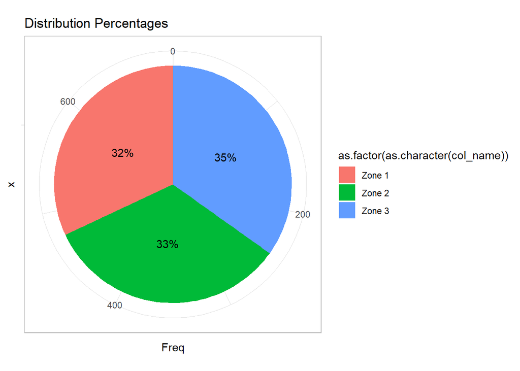

```r
plt = plot_distrib(linear_regress_data$region)
print(plt)
```

The region spread is similar to the initial spread with a single percentage increase in `Zone 3`

2. **marital**

```r
linear_regress_data$marital = ifelse(is.na(linear_regress_data$marital),calc_mod(linear_regress_data$marital),                      linear_regress_data$marital)

# confirm if there is still na data in region
if(any(is.na(linear_regress_data$marital))){
  print("There are still na values")
}else{
  print("There are no na values")
}
```

```
## [1] "There are no na values"
```

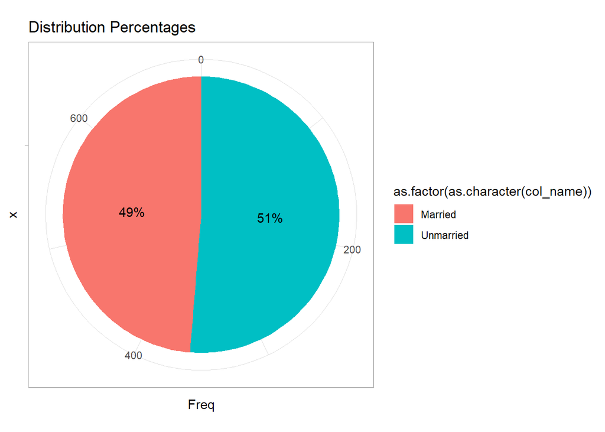

```r
plt = plot_distrib(linear_regress_data$marital)
print(plt)
```

The spread remains consistent with the spread before imputation

3. **retire**

```r
linear_regress_data$retire = ifelse(is.na(linear_regress_data$retire),calc_mod(linear_regress_data$retire),                      linear_regress_data$retire)

# confirm if there is still na data in region
if(any(is.na(linear_regress_data$retire))){
  print("There are still na values")
}else{
  print("There are no na values")
}
```

```
## [1] "There are no na values"
```

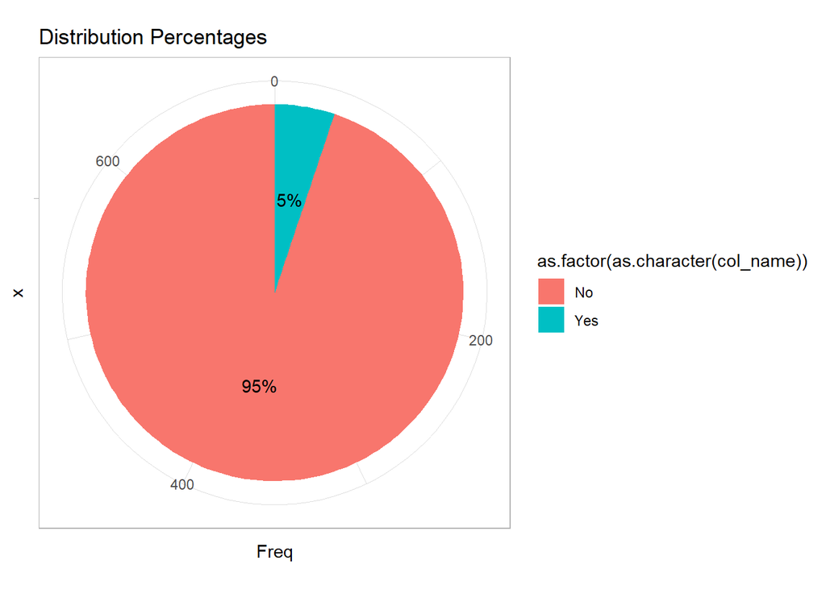

```r
plt = plot_distrib(linear_regress_data$retire)
print(plt)
```

4. **gender**

```r
linear_regress_data$gender = ifelse(is.na(linear_regress_data$gender),calc_mod(linear_regress_data$gender),                      linear_regress_data$gender)

# confirm if there is still na data in region
if(any(is.na(linear_regress_data$gender))){
  print("There are still na values")
}else{
  print("There are no na values")
}
```

```
## [1] "There are no na values"
```

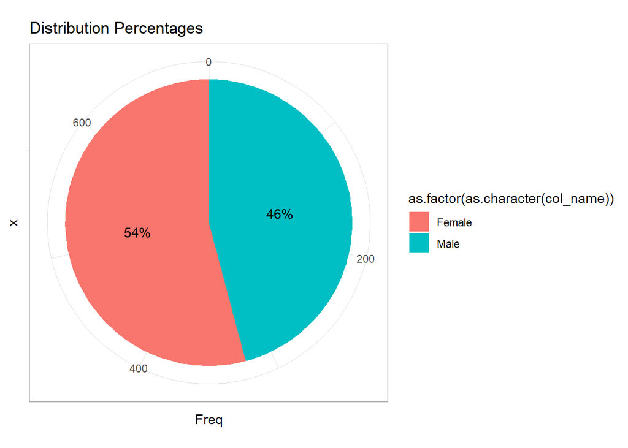

```r
plt = plot_distrib(linear_regress_data$gender)
print(plt)
```

5. **tollfree**

```r
linear_regress_data$tollfree = ifelse(is.na(linear_regress_data$tollfree),calc_mod(linear_regress_data$tollfree),                      linear_regress_data$tollfree)

# confirm if there is still na data in region
if(any(is.na(linear_regress_data$tollfree))){
  print("There are still na values")
}else{
  print("There are no na values")
}
```

```
## [1] "There are no na values"
```

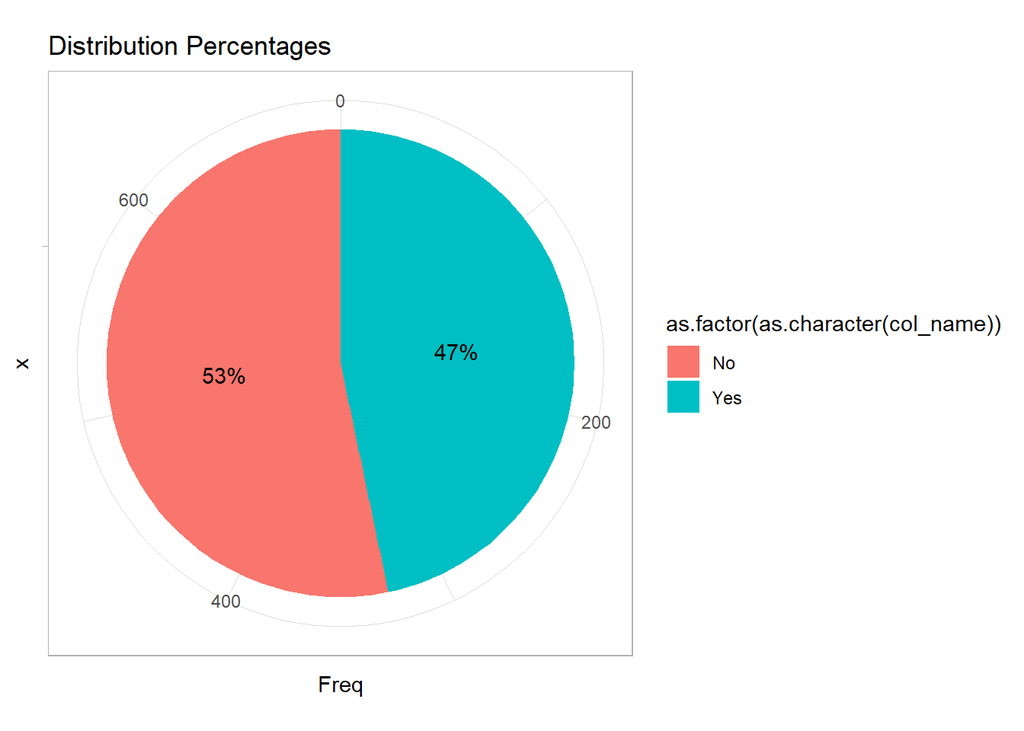

```r
plt = plot_distrib(linear_regress_data$tollfree)
print(plt)
```

6. **custcat**

```r
linear_regress_data$custcat = ifelse(is.na(linear_regress_data$custcat),calc_mod(linear_regress_data$custcat),                      linear_regress_data$custcat)

# confirm if there is still na data in region
if(any(is.na(linear_regress_data$custcat))){
  print("There are still na values")
}else{
  print("There are no na values")
}
```

```
## [1] "There are no na values"
```

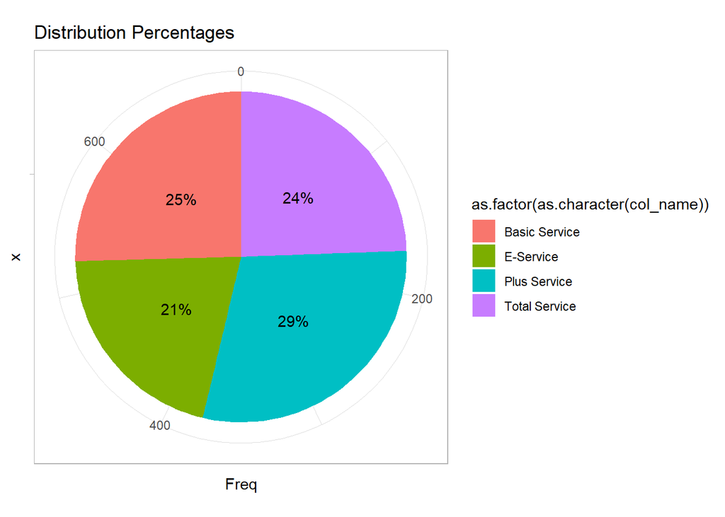

```r
plt = plot_distrib(linear_regress_data$custcat)
print(plt)
```

7. **churn**

```r
linear_regress_data$churn = ifelse(is.na(linear_regress_data$churn),calc_mod(linear_regress_data$churn),                      linear_regress_data$churn)

# confirm if there is still na data in region
if(any(is.na(linear_regress_data$churn))){
  print("There are still na values")
}else{
  print("There are no na values")
}
```

```
## [1] "There are no na values"
```

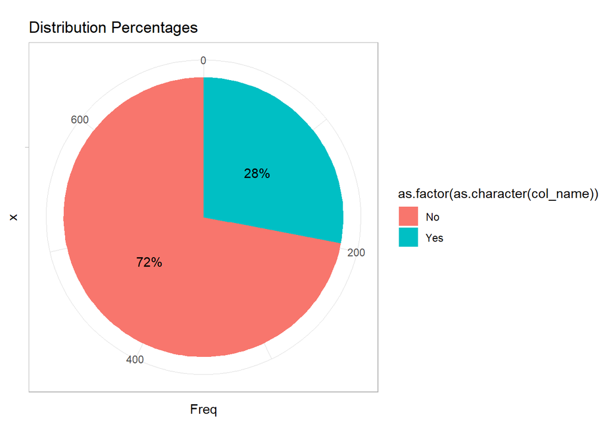

```r
plt = plot_distrib(linear_regress_data$churn)
print(plt)
```

### Encode these factor columns

```r
char_columns
```

```
## [1] "region"   "marital"  "retire"   "gender"   "tollfree" "custcat"  "churn"
```

1. **Region**

```r
unique(linear_regress_data$region)
```

```
## [1] "Zone 2" "Zone 3" "Zone 1"
```

```r
linear_regress_data$region = ifelse(linear_regress_data$region == "Zone 1", 1, ifelse(
  linear_regress_data$region == "Zone 2", 2, ifelse(
    linear_regress_data$region == "Zone 3", 3, linear_regress_data$region
  )
))
```

2. **marital**

```r
unique(linear_regress_data$marital)
```

```
## [1] "Unmarried" "Married"
```

```r
linear_regress_data$marital = ifelse(linear_regress_data$marital == "Unmarried", 1, ifelse(
  linear_regress_data$marital == "Married", 2, linear_regress_data$marital
  )
)
```

3. **retire**

```r
unique(linear_regress_data$retire)
```

```
## [1] "No"  "Yes"
```

```r
linear_regress_data$retire = ifelse(linear_regress_data$retire == "No", 1, ifelse(
  linear_regress_data$retire == "Yes", 2, linear_regress_data$retire
  )
)
```

4. **gender**

```r
unique(linear_regress_data$gender)
```

```
## [1] "Female" "Male"
```

```r
linear_regress_data$gender = ifelse(linear_regress_data$gender == "Female", 1, ifelse(
  linear_regress_data$gender == "Male", 2, linear_regress_data$gender
  )
)
```

5. **tollfree**

```r
unique(linear_regress_data$tollfree)
```

```
## [1] "No"  "Yes"
```

```r
linear_regress_data$tollfree = ifelse(linear_regress_data$tollfree == "No", 1, ifelse(
  linear_regress_data$tollfree == "Yes", 2, linear_regress_data$tollfree
  )
)
```

6. **custcat**

```r
unique(linear_regress_data$custcat)
```

```
## [1] "Plus Service"  "Total Service" "E-Service"     "Basic Service"
```

```r
linear_regress_data$custcat = ifelse(linear_regress_data$custcat == "Plus Service", 1, ifelse(
  linear_regress_data$custcat == "Total Service", 2,ifelse(
  linear_regress_data$custcat == "E-Service", 3,ifelse(
  linear_regress_data$custcat == "Basic Service", 4, linear_regress_data$custcat
  )
)))
```

7. **churn**

```r
unique(linear_regress_data$churn)
```

```
## [1] "No"  "Yes"
```

```r
linear_regress_data$churn = ifelse(linear_regress_data$churn == "No", 1, ifelse(
  linear_regress_data$churn == "Yes", 2, linear_regress_data$churn
  )
)
```

### Convert the character columns to factor columns

```r
linear_regress_data = linear_regress_data %>% mutate(across(all_of(char_columns), as.factor))
head(linear_regress_data)
```

```
## # A tibble: 6 × 19
##   region tenure   age marital address income employ retire gender reside
##   <fct>   <dbl> <dbl> <fct>     <dbl>  <dbl>  <dbl> <fct>  <fct>   <dbl>
## 1 2          68    60 1            40    262     39 1      1           1
## 2 3          25    30 1             0     20      4 1      1           1
## 3 3          33    26 1             5     46      1 1      1           3
## 4 3          55    52 1            22    127     28 1      1           3
## 5 3          18    69 2            11     58      8 1      2           2
## 6 1          61    59 1            26     89     40 2      1           1
## # ℹ 9 more variables: tollfree <fct>, tollten <dbl>, equipten <dbl>,
## #   cardten <dbl>, wireten <dbl>, loglong <dbl>, logcard <dbl>, custcat <fct>,
## #   churn <fct>
```

### Non_factor columns

```r
non_factor = colnames(linear_regress_data %>% select_if(is.numeric))
non_factor
```

```
##  [1] "tenure"   "age"      "address"  "income"   "employ"   "reside"
##  [7] "tollten"  "equipten" "cardten"  "wireten"  "loglong"  "logcard"
```

```r
# using a density plot to assess the distribution of the data

plot_density = function(data_set,num_col){
  ggplot(data_set, aes(x = data_set[[num_col]]))+
    geom_density(fill = "lightblue", color = "blue")+
    ggtitle(paste("Density Plot of", num_col))+
    xlab(num_col)+
    ylab("Density")+
    theme_minimal()
}
```

1. **Tenure**

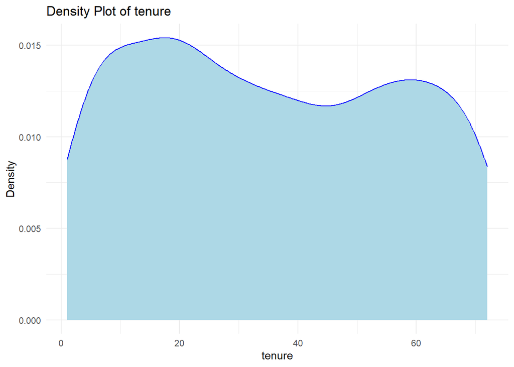

```r
# plot

plot_density(linear_regress_data,"tenure")
```

```r
# IMPUTE data
set.seed(123)
rand_val = function(data, column_name, low = 0, up = 1){
  data[[column_name]] = ifelse(is.na(data[[column_name]]), runif(sum(is.na(data[[column_name]])), min = low, max = up), data[[column_name]])
  return(data)
}
```

```r
linear_regress_data=rand_val(linear_regress_data, "tenure")

if(any(is.na(linear_regress_data$tenure))){
  print(paste("there are na values", "tenure"))
}else{
  print(paste("there are no na values", "tenure"))
}
```

```
## [1] "there are no na values tenure"
```

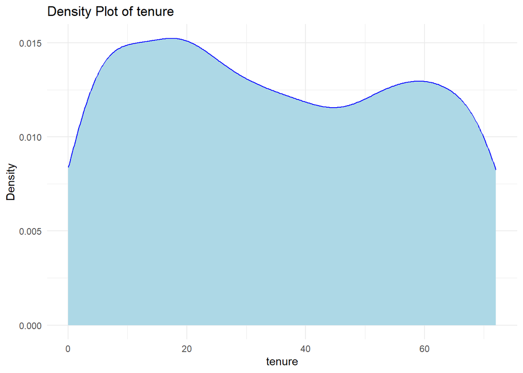

```r
# new disribution of tenure
plot_density(linear_regress_data, "tenure")
```

2. **age**

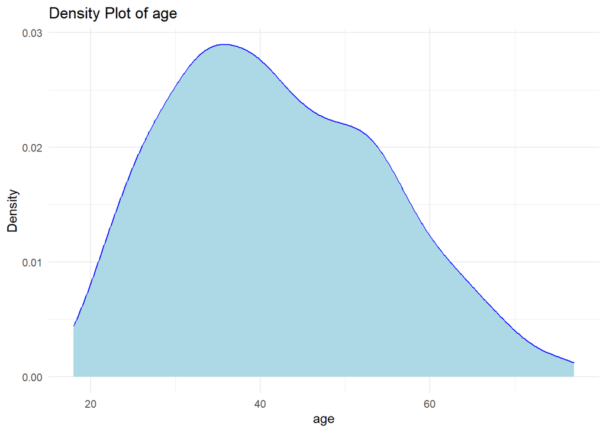

```r
plot_density(linear_regress_data, "age")
```

```r
linear_regress_data = rand_val(linear_regress_data, "age")

if(any(is.na(linear_regress_data$tenure))){
  print(paste("there are na values", "age"))
}else{
  print(paste("there are no na values", "age"))
}
```

```
## [1] "there are no na values age"
```

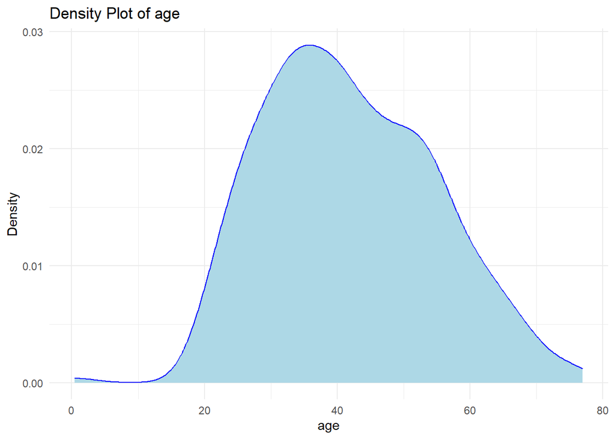

```r
plot_density(linear_regress_data, "age")
```

3. **address**

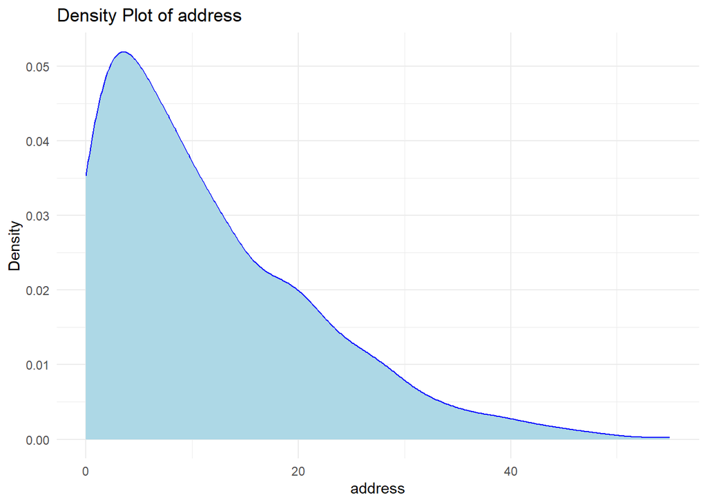

```r
plot_density(linear_regress_data, "address")
```

```r
linear_regress_data = rand_val(linear_regress_data, "address")

if(any(is.na(linear_regress_data$tenure))){
  print(paste("there are na values", "address"))
}else{
  print(paste("there are no na values", "address"))
}
```

```
## [1] "there are no na values address"
```

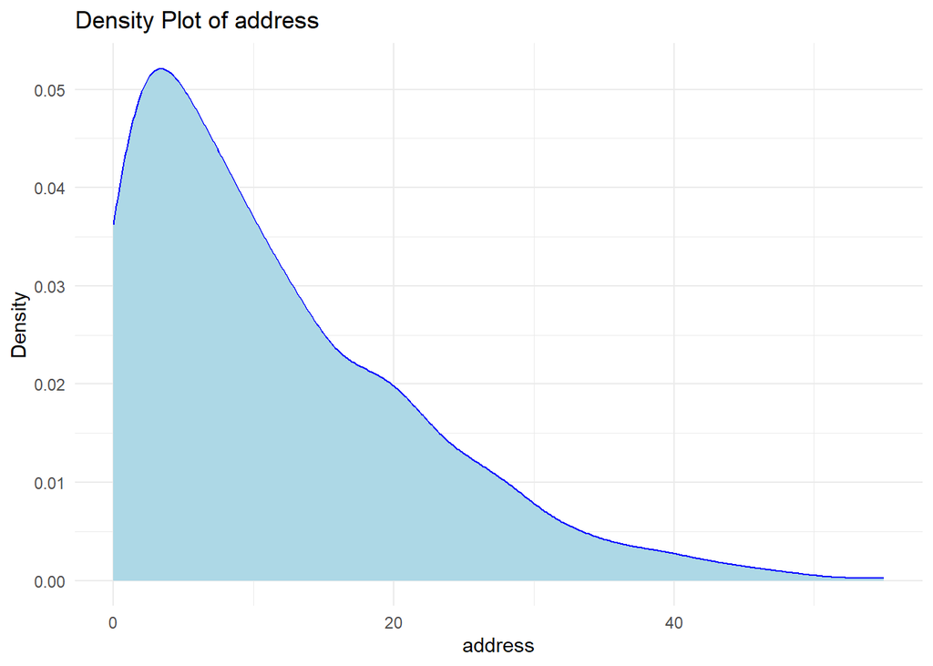

```r
plot_density(linear_regress_data, "address")
```

4. **income**

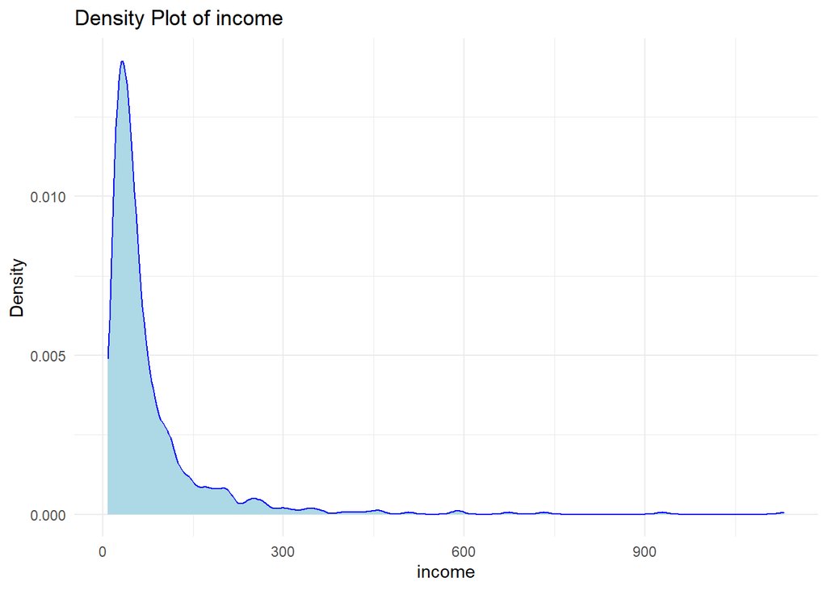

```r
plot_density(linear_regress_data, "income")
```

```r
linear_regress_data = rand_val(linear_regress_data, "income")

if(any(is.na(linear_regress_data$income))){
  print(paste("there are na values", "income"))
}else{
  print(paste("there are no na values", "income"))
}
```

```
## [1] "there are no na values income"
```

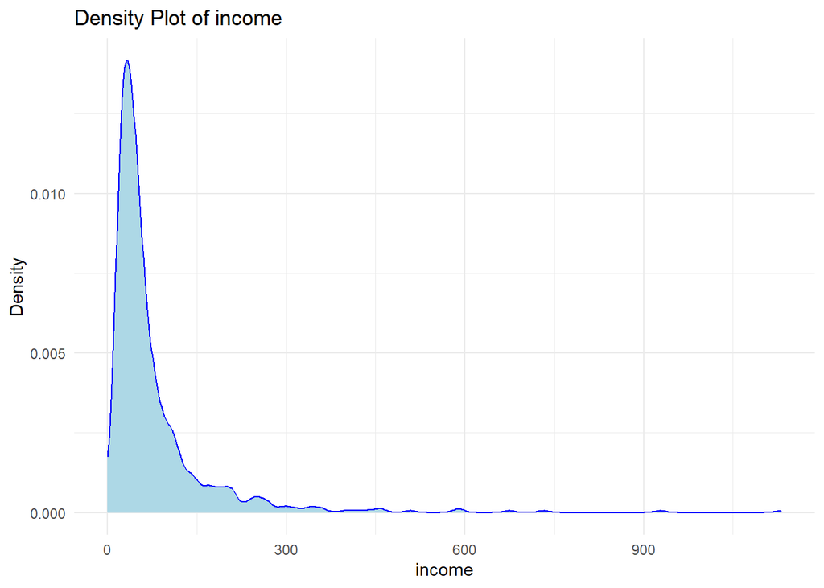

```r
plot_density(linear_regress_data, "income")
```

5. **employ**

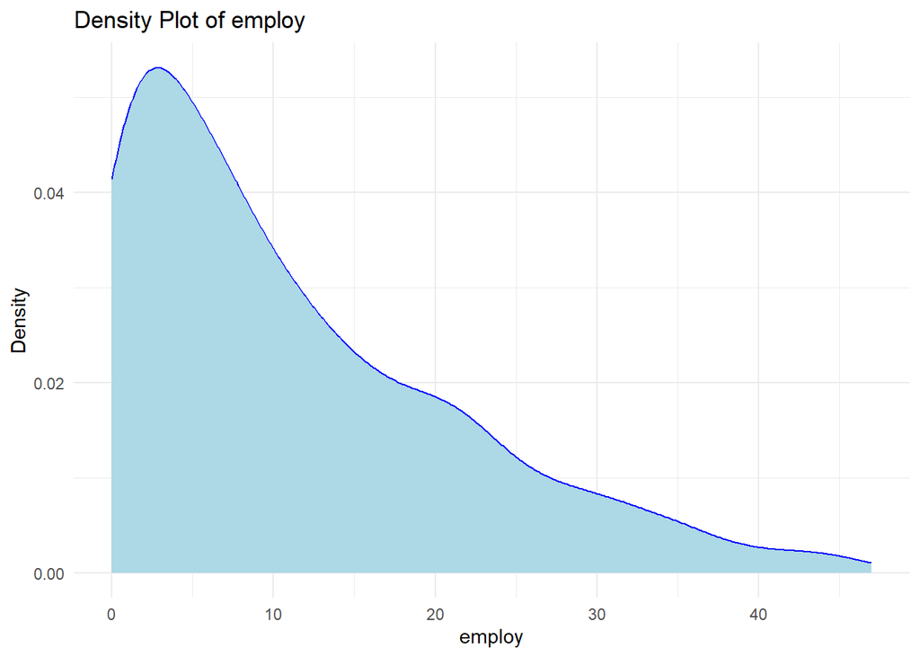

```r
plot_density(linear_regress_data, "employ")
```

```r
linear_regress_data = rand_val(linear_regress_data, "employ")

if(any(is.na(linear_regress_data$employ))){
  print(paste("there are na values", "employ"))
}else{
  print(paste("there are no na values", "employ"))
}
```

```
## [1] "there are no na values employ"
```

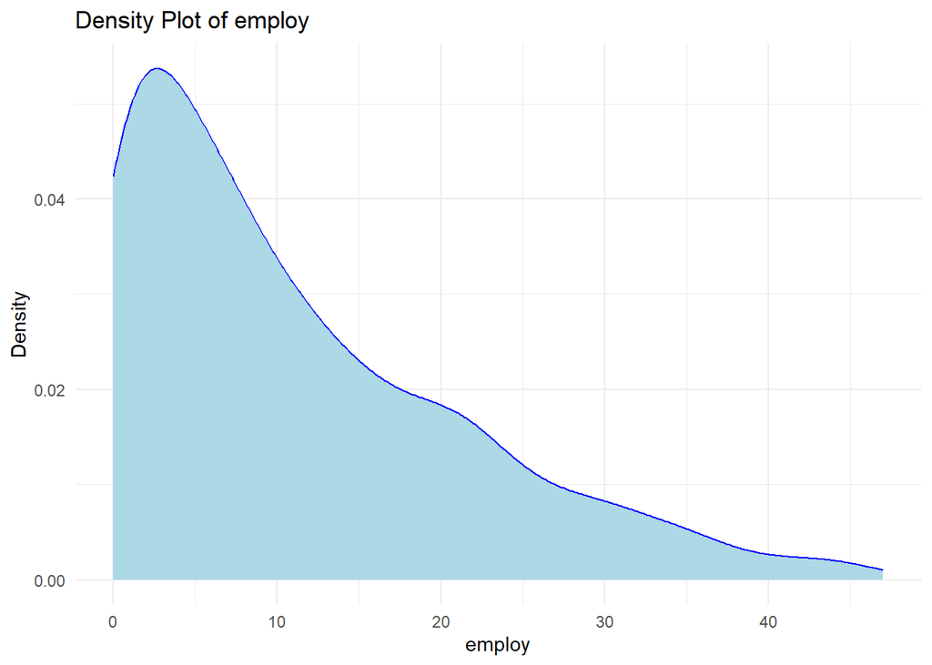

```r
plot_density(linear_regress_data, "employ")
```

6. **reside**

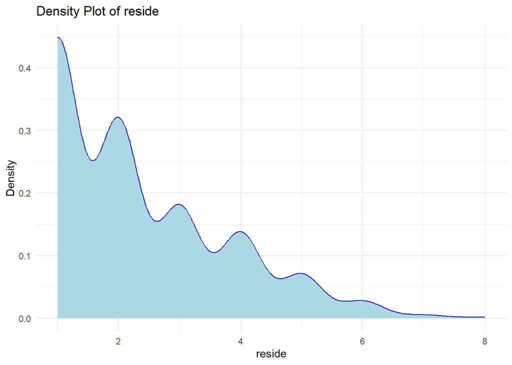

```r
plot_density(linear_regress_data, "reside")
```

```r
linear_regress_data = rand_val(linear_regress_data, "reside")

if(any(is.na(linear_regress_data$reside))){
  print(paste("there are na values", "reside"))
}else{
  print(paste("there are no na values", "reside"))
}
```

```
## [1] "there are no na values reside"
```

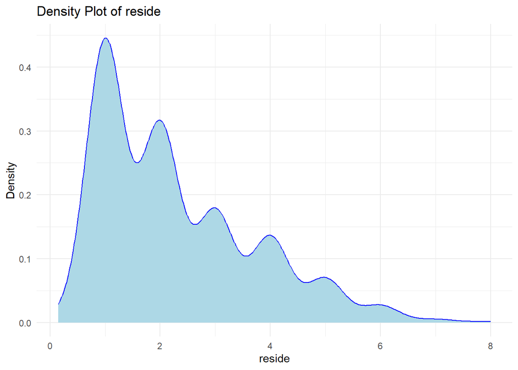

```r
plot_density(linear_regress_data, "reside")
```

7. **tollten**

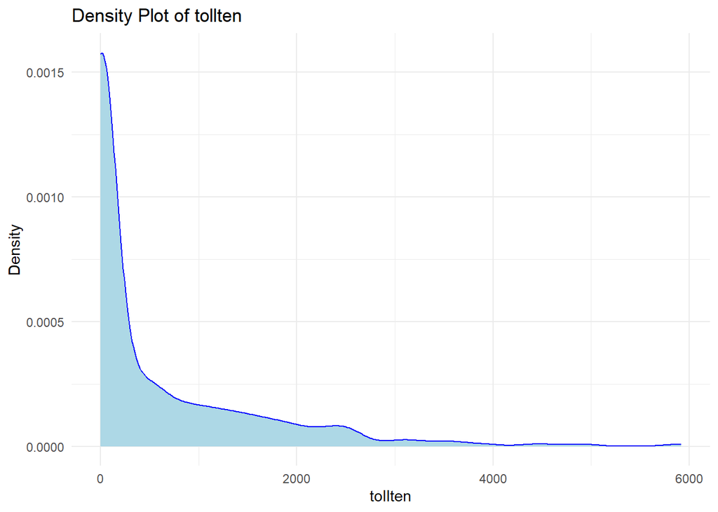

```r
plot_density(linear_regress_data, "tollten")
```

```r
linear_regress_data = rand_val(linear_regress_data, "tollten")

if(any(is.na(linear_regress_data$tollten))){
  print(paste("there are na values", "tollten"))
}else{
  print(paste("there are no na values", "tollten"))
}
```

```
## [1] "there are no na values tollten"
```

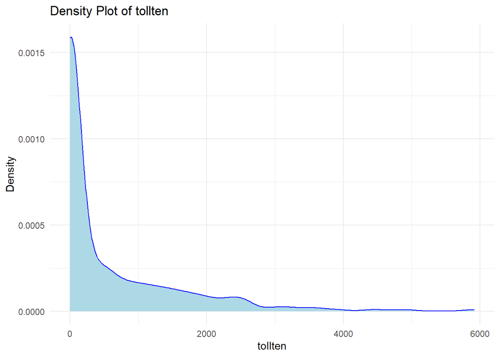

```r
plot_density(linear_regress_data, "tollten")
```

8. **equipten**

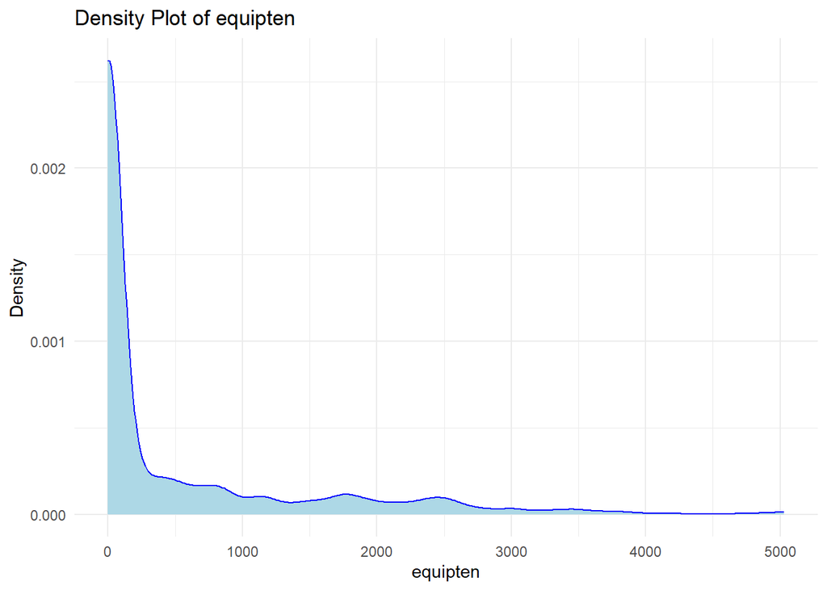

```r
plot_density(linear_regress_data, "equipten")
```

```r
linear_regress_data = rand_val(linear_regress_data, "equipten")

if(any(is.na(linear_regress_data$equipten))){
  print(paste("there are na values", "equipten"))
}else{
  print(paste("there are no na values", "equipten"))
}
```

```
## [1] "there are no na values equipten"
```

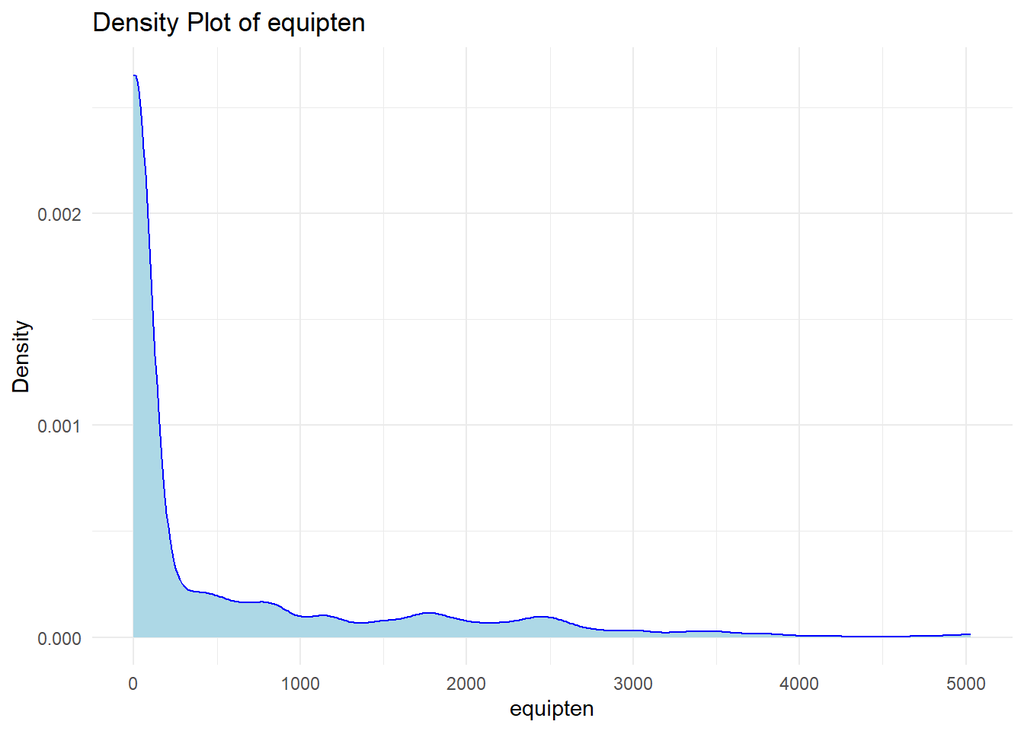

```r
plot_density(linear_regress_data, "equipten")
```

9. **cardten**

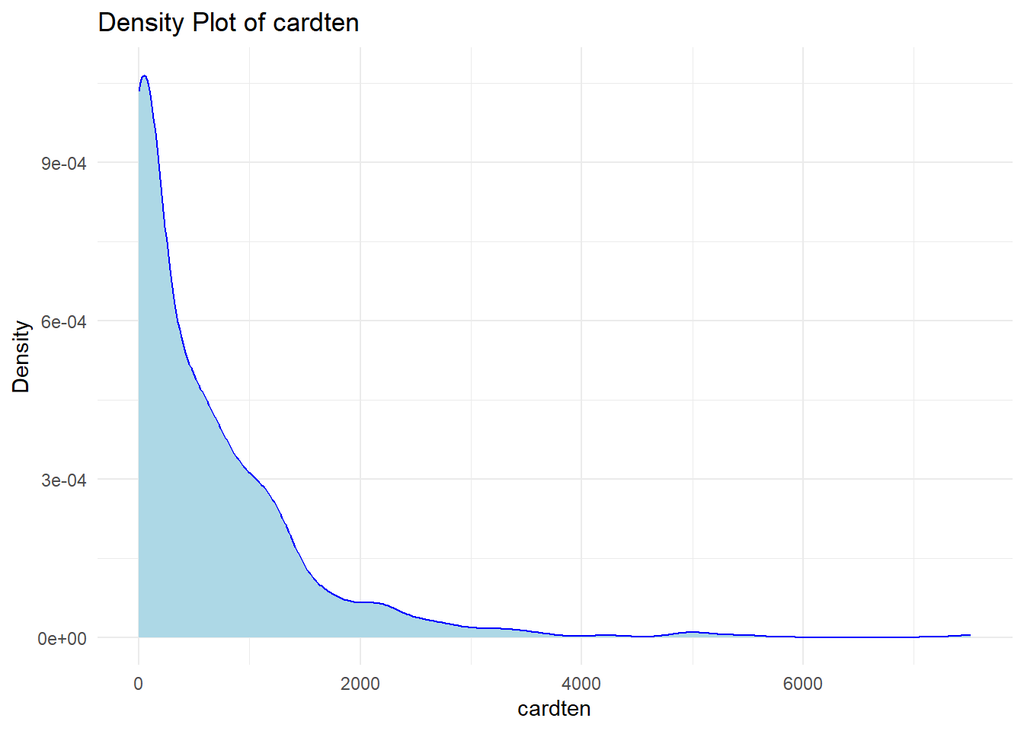

```r
plot_density(linear_regress_data, "cardten")
```

```r
linear_regress_data = rand_val(linear_regress_data, "cardten")

if(any(is.na(linear_regress_data$cardten))){
  print(paste("there are na values", "cardten"))
}else{
  print(paste("there are no na values", "cardten"))
}
```

```
## [1] "there are no na values cardten"
```

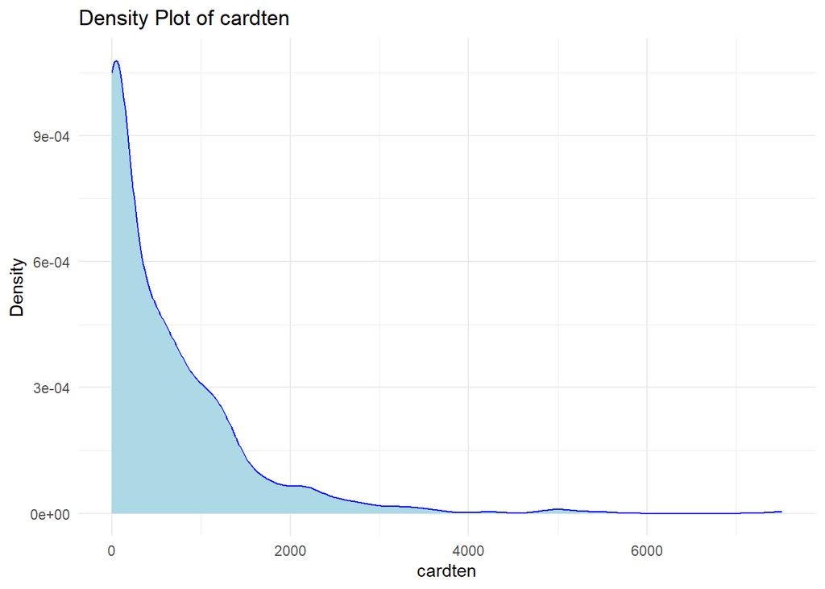

```r
plot_density(linear_regress_data, "cardten")
```

10. **wireten**

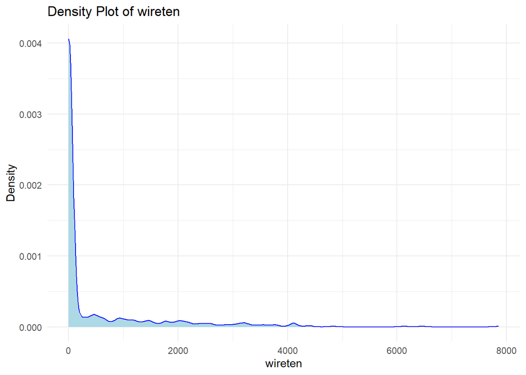

```r
plot_density(linear_regress_data, "wireten")
```

```r
linear_regress_data = rand_val(linear_regress_data, "wireten")

if(any(is.na(linear_regress_data$wireten))){
  print(paste("there are na values", "wireten"))
}else{
  print(paste("there are no na values", "wireten"))
}
```

```
## [1] "there are no na values wireten"
```

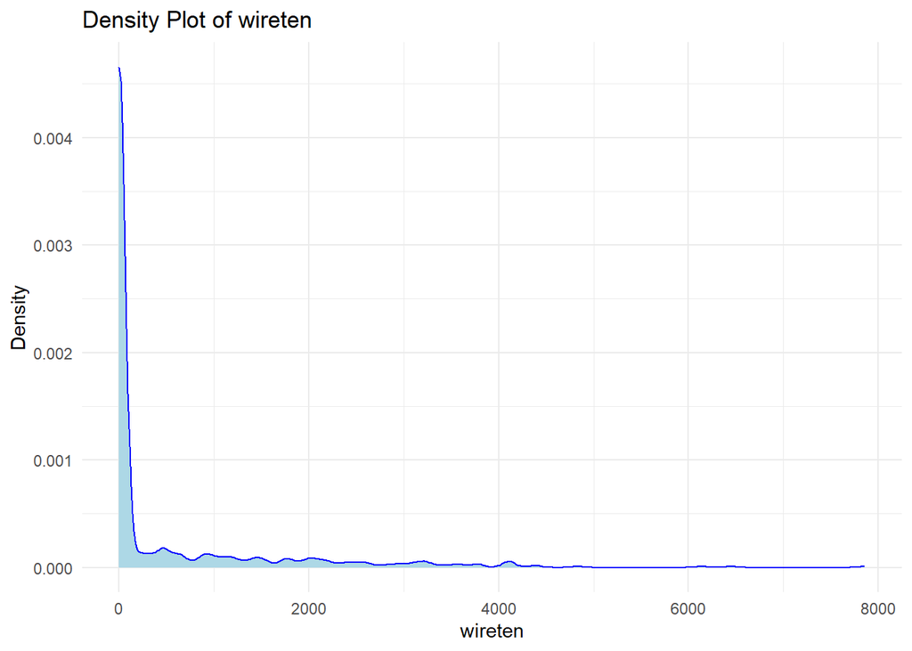

```r
plot_density(linear_regress_data, "wireten")
```

11. **loglong**

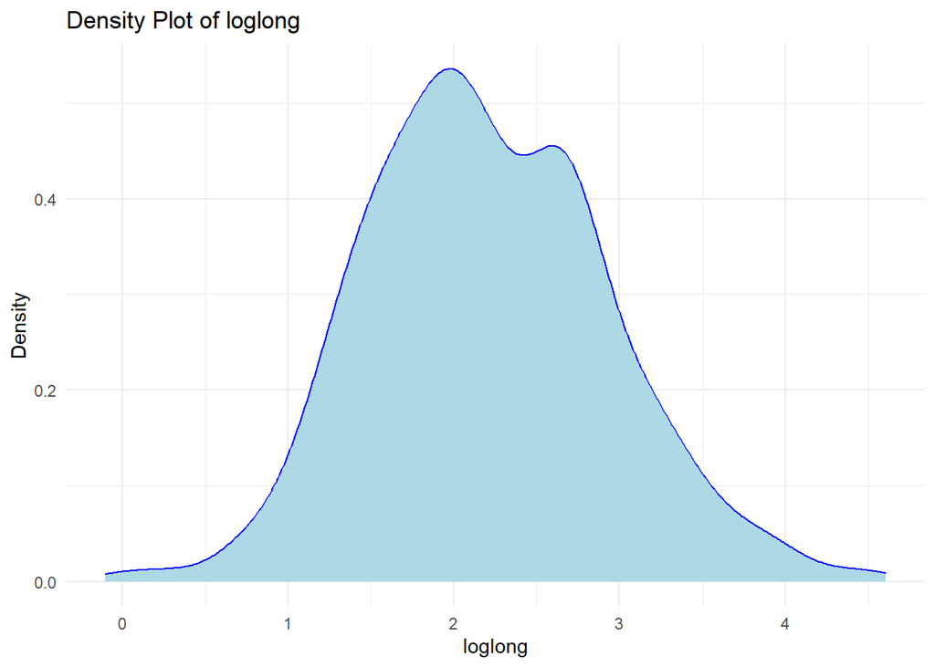

```r
plot_density(linear_regress_data, "loglong")
```

```r
linear_regress_data = rand_val(linear_regress_data, "loglong")

if(any(is.na(linear_regress_data$loglong))){
  print(paste("there are na values", "loglong"))
}else{
  print(paste("there are no na values", "loglong"))
}
```

```
## [1] "there are no na values loglong"
```

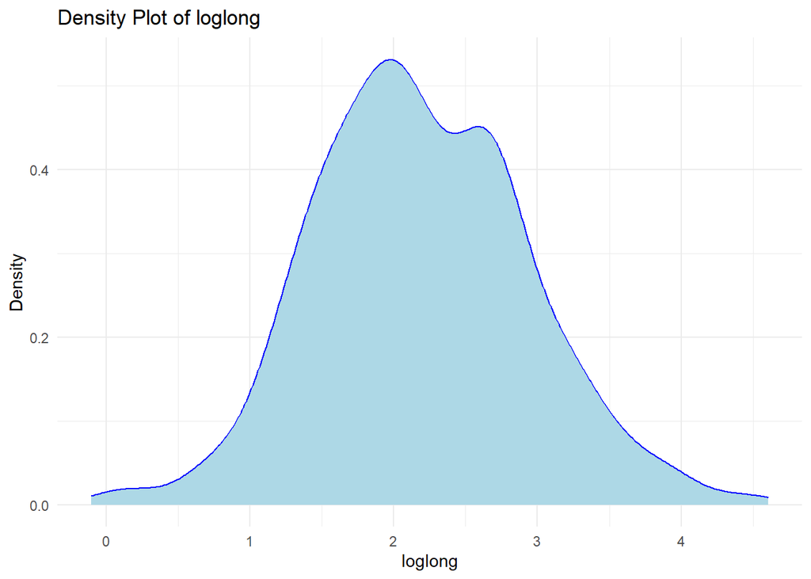

```r
plot_density(linear_regress_data, "loglong")
```

12. **logcard**

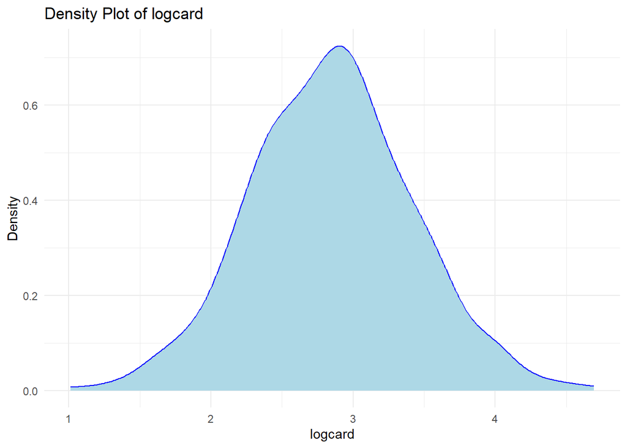

```r
plot_density(linear_regress_data, "logcard")
```

```r
linear_regress_data = rand_val(linear_regress_data, "logcard")

if(any(is.na(linear_regress_data$logcard))){
  print(paste("there are na values", "logcard"))
}else{
  print(paste("there are no na values", "logcard"))
}
```

```
## [1] "there are no na values logcard"
```

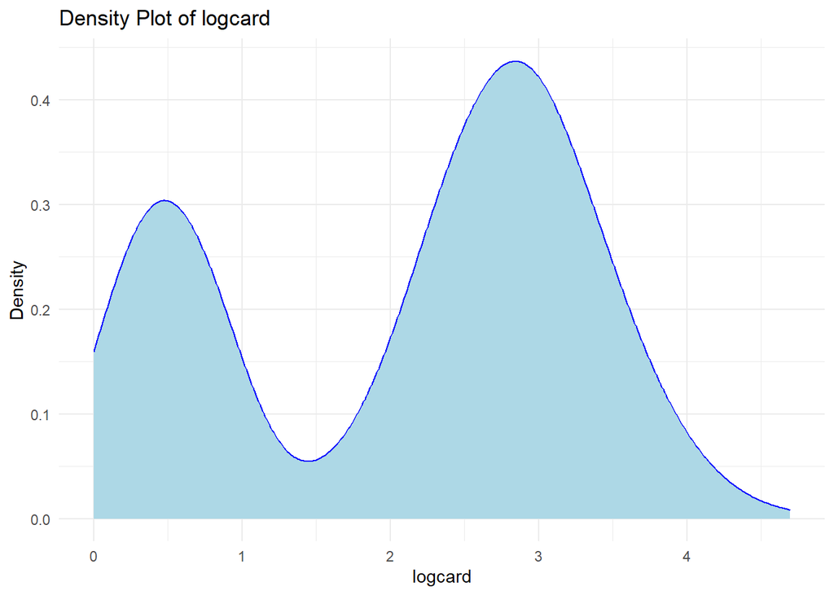

```r
plot_density(linear_regress_data, "logcard")
```

## 4. Linear Regression Assumptions

For the linear regression the aim is to determine `age` based on the other variables in the linear regression data set

### a. Homoscedasticity

```r
# round off all values that are not
# Age - 3
# employ - 7
# address - 5
# Tenure - 2
# income - 6
# reside - 10
linear_regress_data[, c(3, 7, 5, 2, 6,10)][,
                                            sapply(linear_regress_data[, c(3, 7, 5, 2, 6, 10)], is.numeric)] = round(linear_regress_data[, c(3, 7, 5, 2, 6, 10)][,
                                            sapply(linear_regress_data[, c(3, 7, 5, 2, 6, 10)], is.numeric)])
```

```r
linear_regress_model = lm(age~., data = linear_regress_data)
summary(linear_regress_model)
```

```
##
## Call:
## lm(formula = age ~ ., data = linear_regress_data)
##
## Residuals:
##     Min      1Q  Median      3Q     Max
## -39.193  -5.109  -1.235   4.893  27.673
##
## Coefficients:
##               Estimate Std. Error t value Pr(>|t|)
## (Intercept)  2.991e+01  1.732e+00  17.272  < 2e-16 ***
## region2      2.603e-01  7.312e-01   0.356 0.721917
## region3      3.709e-01  7.218e-01   0.514 0.607517
## tenure       3.469e-02  2.851e-02   1.217 0.223979
## marital2     2.599e+00  7.502e-01   3.465 0.000564 ***
## address      4.282e-01  3.734e-02  11.467  < 2e-16 ***
## income       7.006e-03  3.836e-03   1.826 0.068226 .
## employ       4.704e-01  4.204e-02  11.189  < 2e-16 ***
## retire2      1.325e+01  1.498e+00   8.847  < 2e-16 ***
## gender2      1.169e+00  5.900e-01   1.981 0.048002 *
## reside      -1.293e+00  2.681e-01  -4.821 1.77e-06 ***
## tollfree2    2.191e-01  9.864e-01   0.222 0.824293
## tollten     -2.308e-04  5.508e-04  -0.419 0.675345
## equipten     3.905e-04  4.589e-04   0.851 0.395090
## cardten     -1.651e-04  5.989e-04  -0.276 0.782867
## wireten      1.154e-05  4.577e-04   0.025 0.979891
## loglong     -6.816e-01  7.210e-01  -0.945 0.344878
## logcard      7.859e-01  3.902e-01   2.014 0.044415 *
## custcat2    -7.650e-01  9.837e-01  -0.778 0.437017
## custcat3     4.969e-01  1.020e+00   0.487 0.626196
## custcat4     7.346e-01  9.882e-01   0.743 0.457520
## churn2      -1.506e-02  7.283e-01  -0.021 0.983508
## ---
## Signif. codes:  0 '***' 0.001 '**' 0.01 '*' 0.05 '.' 0.1 ' ' 1
##
## Residual standard error: 7.713 on 678 degrees of freedom
## Multiple R-squared:  0.6483, Adjusted R-squared:  0.6374
## F-statistic: 59.51 on 21 and 678 DF,  p-value: < 2.2e-16
```

Based on this output the correlation of all columns of the data set has a covariance matrix of `0.8050466` with a distribution away from `0` because of the first quartile at `-5.1` and third quatile at `4.9`

```r
# using the key predictor values only
linear_regress_model_2 = lm(age~marital + address + employ + retire+ gender + reside + logcard, data = linear_regress_data)
summary(linear_regress_model_2)
```

```
##
## Call:
## lm(formula = age ~ marital + address + employ + retire + gender +
##     reside + logcard, data = linear_regress_data)
##
## Residuals:
##     Min      1Q  Median      3Q     Max
## -40.175  -5.065  -1.337   4.783  27.581
##
## Coefficients:
##             Estimate Std. Error t value Pr(>|t|)
## (Intercept) 30.44647    0.87914  34.632  < 2e-16 ***
## marital2     2.59271    0.73343   3.535 0.000435 ***
## address      0.43766    0.03421  12.793  < 2e-16 ***
## employ       0.51375    0.03277  15.678  < 2e-16 ***
## retire2     12.10865    1.40329   8.629  < 2e-16 ***
## gender2      1.11609    0.58460   1.909 0.056657 .
## reside      -1.32827    0.26512  -5.010 6.92e-07 ***
## logcard      0.63613    0.25814   2.464 0.013971 *
## ---
## Signif. codes:  0 '***' 0.001 '**' 0.01 '*' 0.05 '.' 0.1 ' ' 1
##
## Residual standard error: 7.685 on 692 degrees of freedom
## Multiple R-squared:  0.6437, Adjusted R-squared:  0.6401
## F-statistic: 178.6 on 7 and 692 DF,  p-value: < 2.2e-16
```

```r
linear_regress_model_3 = lm(age~marital + address + employ + retire+ reside + logcard, data = linear_regress_data)
summary(linear_regress_model_3)
```

```
##
## Call:
## lm(formula = age ~ marital + address + employ + retire + reside +
##     logcard, data = linear_regress_data)
##
## Residuals:
##     Min      1Q  Median      3Q     Max
## -39.607  -4.993  -1.230   4.706  27.605
##
## Coefficients:
##             Estimate Std. Error t value Pr(>|t|)
## (Intercept) 30.99493    0.83246  37.233  < 2e-16 ***
## marital2     2.57181    0.73475   3.500 0.000495 ***
## address      0.43684    0.03427  12.746  < 2e-16 ***
## employ       0.51037    0.03278  15.568  < 2e-16 ***
## retire2     12.06170    1.40574   8.580  < 2e-16 ***
## reside      -1.33251    0.26562  -5.017 6.69e-07 ***
## logcard      0.65151    0.25851   2.520 0.011950 *
## ---
## Signif. codes:  0 '***' 0.001 '**' 0.01 '*' 0.05 '.' 0.1 ' ' 1
##
## Residual standard error: 7.699 on 693 degrees of freedom
## Multiple R-squared:  0.6418, Adjusted R-squared:  0.6387
## F-statistic:   207 on 6 and 693 DF,  p-value: < 2.2e-16
```

#### Test

```r
any(is.na(linear_regress_data))
```

```
## [1] FALSE
```

```r
library(lmtest)
homoscedastisty_test = bptest(linear_regress_model)
homoscedastisty_test
```

```
##
##  studentized Breusch-Pagan test
##
## data:  linear_regress_model
## BP = 30.653, df = 21, p-value = 0.07962
```

```r
homoscedastisty_test_2 = bptest(linear_regress_model_2)
homoscedastisty_test_2
```

```
##
##  studentized Breusch-Pagan test
##
## data:  linear_regress_model_2
## BP = 30.378, df = 7, p-value = 8.093e-05
```

```r
homoscedastisty_test_3 = bptest(linear_regress_model_3)
homoscedastisty_test_3
```

```
##
##  studentized Breusch-Pagan test
##
## data:  linear_regress_model_3
## BP = 31.952, df = 6, p-value = 1.667e-05
```

**Iterpretation**

Breusch-Pagan test

- **Null Hypothesis** $h_o$**:** The null hypothesis of the Breusch-Pagan test is that there is homoscedasticity, meaning that the variance of the residuals is constant across all levels of the independent variable(s).
- **Alternative Hypothesis** $h_1$**:** The alternative hypothesis is that there is heteroscedasticity, meaning that the variance of the residuals is not constant across all levels of the independent variable(s).
- If the p-value is less than `0.05` reject null hypothesis

The better models have less than 0.05 p-value meaning they have `heteroscedasticity` and high variability in the independent variables

### b. Normality

1. **Using QQ-plots**

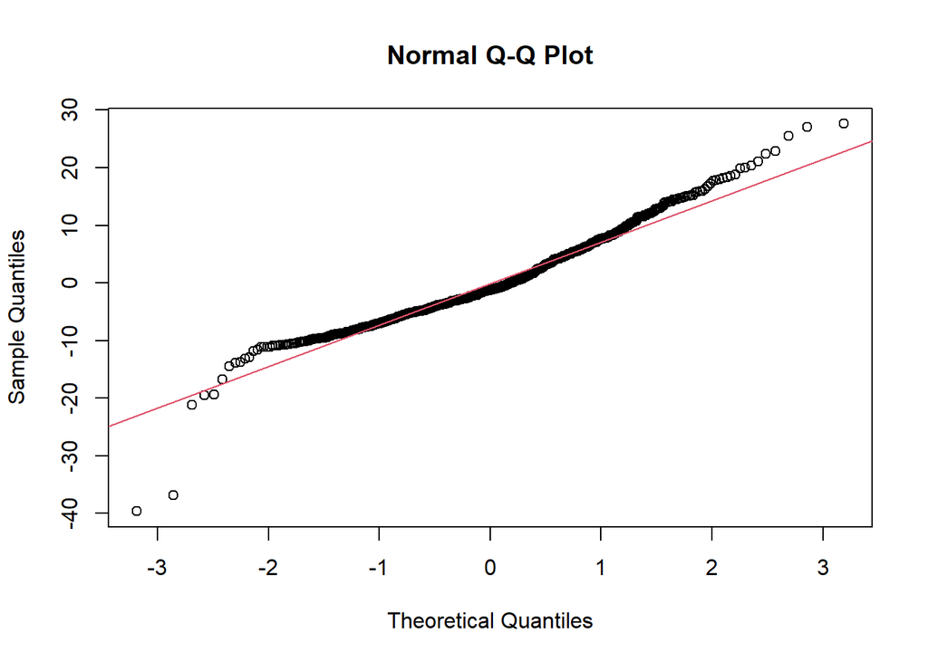

```r
linear_regress_residuals <- residuals(linear_regress_model_3)

# QQ plot
qqnorm(linear_regress_residuals)
qqline(linear_regress_residuals, col = 2)
```

Most point lie on the qq line meaning the data is `normaly distributed`

### c. linearity

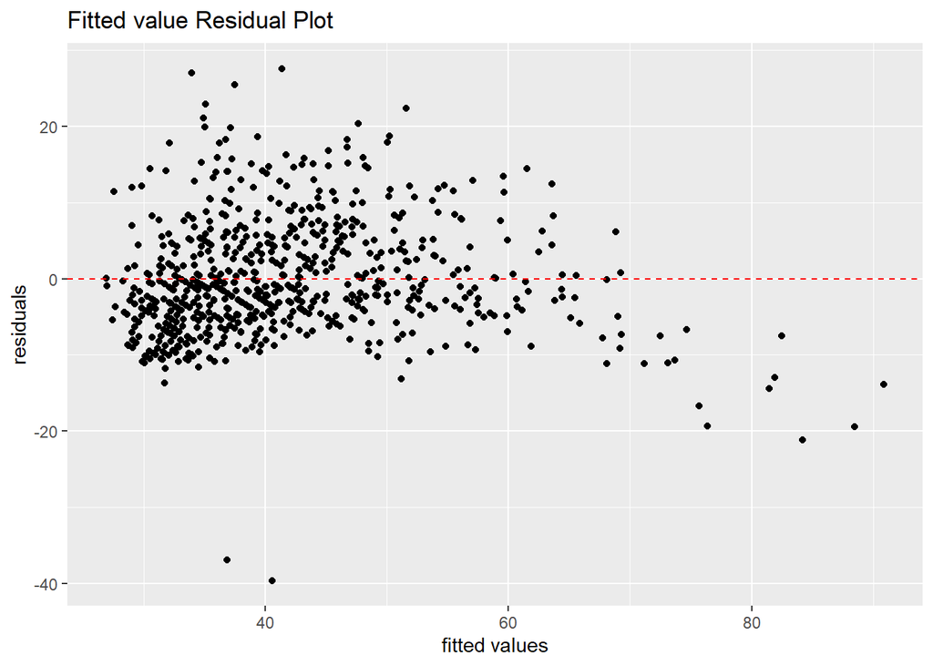

```r
# residuals fitted value plot
library(ggplot2)

res_fit = data.frame(fitted = linear_regress_model_3$fitted.values,
                     residual = linear_regress_model_3$residuals)

ggplot(data = res_fit,
       aes(x = fitted, y = residual)) +
  geom_point()+
  geom_hline(yintercept = 0, linetype = "dashed", color = "red") +
  labs(
    x = "fitted values",
    y = "residuals",
    title = "Fitted value Residual Plot"
  )
```

Most values lie around the red line meaning the data is `Normally distributed`

### d. Multi-co-linearity

Using **Variance inflation plots** how much the variance of a regression coefficient is inflated due to multicollinearity.

```r
library(car, warn.conflicts = FALSE)
var_inf = vif(linear_regress_model_3)
var_inf
```

```
##  marital  address   employ   retire   reside  logcard
## 1.592688 1.423730 1.348718 1.138379 1.653813 1.143030
```

The variance inflation factor for each of the variables is `less than 5` indicating that the variables are not affected by variance inflation due to **multi-colinearity**

### e. Confirm accuracy of model

```r
test= na.omit(test)
# age~marital + address + employ + retire+ reside + logcard
test$marital = ifelse(test$marital == "Unmarried", 1, ifelse(
  test$marital == "Married", 2, test$marital
))
test$retire = ifelse(test$retire == "No", 1, ifelse(
  test$retire == "Yes", 2, test$retire
))
predict_mod = predict(linear_regress_model_3,
                       test)
predict_mod = ifelse(predict_mod > 0.5, 1, 0)

actual_lm_val = test$age
mse = mean((predict_mod - actual_lm_val)^2)
rmse = sqrt(mse)

cat("The mean squared error is", mse, " with a rmse of ", rmse)
```

```
## The mean squared error is 1902.819  with a rmse of  43.62131
```

```r
age_range = max(Telecommunication_Data$age, na.rm = TRUE) - min(Telecommunication_Data$age, na.rm = TRUE)
age_range
```

```
## [1] 59
```

Because the dependent variable range of `59` is larger than the RMSE of the regression model using linear regression model 3 of `43.62131` the model does not need any further tweaking to increase the accuracy of the model

## 5. GLMs

### 1. Logistic Binomial

A statistical method used for binary classification tasks

Dependent variable is categorical and has only two possible outcomes, usually coded as 0 and 1.

The logistic regression model uses the logistic function (also known as the sigmoid function) to model the relationship between the predictor variables and the probability of the binary outcome.

$$P(y = 1|x) = \frac{1}{1+e^{-(B_0 + B_1x_1+ B_2x_2+ B_3x_3+ ...+ B_nx_n}}$$

**Where:**

- **P(y = 1|x)** is the probability of the dependent variable being 1 given the values of predictor variables X.
- $B_0, B_1, B_2,B_3, …$ are coefficients estimated by the model.
- $x_1, x_2, x_3, x_4, …$ the predictor variables

```r
binom_regress_data = linear_regress_data
```

#### a. Select the dependent variable

The model tries to predict `marital status` based on the other variables.

- Unmarried `1` will become 1
- Married `2` will become 0

```r
# encoding marital
binom_regress_data$marital = ifelse(binom_regress_data$marital == 1, 1, 0)
min(binom_regress_data$marital)
```

```
## [1] 0
```

```r
max(binom_regress_data$marital)
```

```
## [1] 1
```

#### b. Fit the logistic regression model

```r
binom_model = glm(marital~., data = binom_regress_data, family = "binomial")
summary(binom_model)
```

```
##
## Call:
## glm(formula = marital ~ ., family = "binomial", data = binom_regress_data)
##
## Coefficients:
##               Estimate Std. Error z value Pr(>|z|)
## (Intercept)  6.107e+00  8.149e-01   7.493 6.72e-14 ***
## region2      3.332e-01  2.565e-01   1.299 0.193946
## region3      3.335e-01  2.484e-01   1.342 0.179500
## tenure       6.778e-03  9.847e-03   0.688 0.491205
## age         -4.684e-02  1.337e-02  -3.504 0.000458 ***
## address     -5.467e-03  1.355e-02  -0.404 0.686540
## income       1.440e-03  1.339e-03   1.075 0.282201
## employ       3.072e-02  1.559e-02   1.971 0.048705 *
## retire2      1.214e+00  5.286e-01   2.296 0.021680 *
## gender2      1.796e-01  2.078e-01   0.864 0.387340
## reside      -1.548e+00  1.213e-01 -12.760  < 2e-16 ***
## tollfree2   -1.566e-02  3.415e-01  -0.046 0.963422
## tollten     -8.004e-05  1.863e-04  -0.430 0.667451
## equipten    -1.983e-04  1.537e-04  -1.290 0.196963
## cardten     -2.254e-04  1.999e-04  -1.128 0.259404
## wireten      3.351e-05  1.468e-04   0.228 0.819435
## loglong     -6.538e-01  2.570e-01  -2.544 0.010951 *
## logcard      2.409e-02  1.389e-01   0.173 0.862299
## custcat2    -4.631e-02  3.378e-01  -0.137 0.890945
## custcat3    -7.529e-02  3.473e-01  -0.217 0.828390
## custcat4    -2.583e-01  3.440e-01  -0.751 0.452761
## churn2      -1.005e-01  2.586e-01  -0.389 0.697457
## ---
## Signif. codes:  0 '***' 0.001 '**' 0.01 '*' 0.05 '.' 0.1 ' ' 1
##
## (Dispersion parameter for binomial family taken to be 1)
##
##     Null deviance: 969.94  on 699  degrees of freedom
## Residual deviance: 602.16  on 678  degrees of freedom
## AIC: 646.16
##
## Number of Fisher Scoring iterations: 5
```

The AIC value is below `1000` meaning the model is highly discriminant to choosing whether a person is married or unmarried

```r
binom_model_2 = glm(marital~age+employ+reside+retire+ logcard, data = binom_regress_data, family = "binomial")
summary(binom_model_2)
```

```
##
## Call:
## glm(formula = marital ~ age + employ + reside + retire + logcard,
##     family = "binomial", data = binom_regress_data)
##
## Coefficients:
##             Estimate Std. Error z value Pr(>|z|)
## (Intercept)  5.51512    0.56056   9.839  < 2e-16 ***
## age         -0.05087    0.01179  -4.315  1.6e-05 ***
## employ       0.02284    0.01238   1.845   0.0650 .
## reside      -1.53113    0.11736 -13.047  < 2e-16 ***
## retire2      0.78710    0.46232   1.702   0.0887 .
## logcard     -0.16398    0.08982  -1.826   0.0679 .
## ---
## Signif. codes:  0 '***' 0.001 '**' 0.01 '*' 0.05 '.' 0.1 ' ' 1
##
## (Dispersion parameter for binomial family taken to be 1)
##
##     Null deviance: 969.94  on 699  degrees of freedom
## Residual deviance: 627.06  on 694  degrees of freedom
## AIC: 639.06
##
## Number of Fisher Scoring iterations: 5
```

This model is more discriminant to the marital status and the accuracy has improved as the AUC is lower than the first model by `1.098799%`

From this model

The `age` and the people `reside` have a negative relation to `marital` will cause the model to more accurately predict `marital`

```r
binom_model_3 = glm(marital~age+reside, data = binom_regress_data, family = "binomial")
summary(binom_model_3)
```

```
##
## Call:
## glm(formula = marital ~ age + reside, family = "binomial", data = binom_regress_data)
##
## Coefficients:
##              Estimate Std. Error z value Pr(>|z|)
## (Intercept)  4.820925   0.484982   9.940  < 2e-16 ***
## age         -0.036052   0.007918  -4.553 5.29e-06 ***
## reside      -1.523851   0.116247 -13.109  < 2e-16 ***
## ---
## Signif. codes:  0 '***' 0.001 '**' 0.01 '*' 0.05 '.' 0.1 ' ' 1
##
## (Dispersion parameter for binomial family taken to be 1)
##
##     Null deviance: 969.94  on 699  degrees of freedom
## Residual deviance: 636.09  on 697  degrees of freedom
## AIC: 642.09
##
## Number of Fisher Scoring iterations: 5
```

```r
binom_model_4 = glm(marital~employ+retire+logcard, data =binom_regress_data, family = "binomial")
summary(binom_model_4)
```

```
##
## Call:
## glm(formula = marital ~ employ + retire + logcard, family = "binomial",
##     data = binom_regress_data)
##
## Coefficients:
##              Estimate Std. Error z value Pr(>|z|)
## (Intercept)  0.301865   0.160241   1.884   0.0596 .
## employ       0.005644   0.008000   0.705   0.4805
## retire2      0.852478   0.383015   2.226   0.0260 *
## logcard     -0.168518   0.066631  -2.529   0.0114 *
## ---
## Signif. codes:  0 '***' 0.001 '**' 0.01 '*' 0.05 '.' 0.1 ' ' 1
##
## (Dispersion parameter for binomial family taken to be 1)
##
##     Null deviance: 969.94  on 699  degrees of freedom
## Residual deviance: 958.33  on 696  degrees of freedom
## AIC: 966.33
##
## Number of Fisher Scoring iterations: 4
```

`model 3` is more accurate than model 1 but less than model 2 although it uses the most discriminant variables

#### b. Model accuracy

```r
binom_test = test
binom_test$marital = ifelse(binom_test$marital == 1, 1, 0)
binom_pred = predict(binom_model_2, test, type = "response")
binom_pred = ifelse(binom_pred > 0.5, 1, 0)

# see prediction model contigency table
binom_cont_tab = table(predicted = binom_pred, actual =  binom_test$marital)

print("Unmarried = 1 and married = 0")
```

```
## [1] "Unmarried = 1 and married = 0"
```

```r
binom_cont_tab
```

```
##          actual
## predicted  0  1
##         0 81  9
##         1 18 74
```

```r
library(caTools)
library(ROCR)
binomial_acc_obj = prediction(binom_pred, binom_test$marital)
binom_auc = performance(binomial_acc_obj, measure = "auc")
binom_auc = binom_auc@y.values[[1]]
binom_auc * 100
```

```
## [1] 85.4874
```

The binomial model is `85.4874%` accurate

```r
# coefficient of linear regression
coef(binom_model_2)
```

```
## (Intercept)         age      employ      reside     retire2     logcard
##  5.51512107 -0.05086726  0.02284421 -1.53112828  0.78709924 -0.16398226
```

### 2. logistic multi-nomial

multi-nomial logistic regression can handle more than two classes

Uses a categorical dependent variable with more than two categories and one or more independent variables.

three or more unordered categories.

```r
multinom_data = linear_regress_data
```

#### a. select the dependent variable

Reside has been choses as it is unordered and has multiple categories from`1` to `8`

```r
library(nnet)
multi_nom_mod = multinom(reside~., data = multinom_data)
summary(multi_nom_mod)
```

```
## Call:
## multinom(formula = reside ~ ., data = multinom_data)
##
## Coefficients:
##   (Intercept)    region2       region3     tenure           age   marital2
## 1   2.8085871 -0.7141456 -4.806062e-01 0.05196236  0.0935919988 -6.2802550
## 2   3.2159726 -0.4594545  5.060336e-05 0.07281899  0.0660997428  0.8991506
## 3   3.4922067 -0.8055852 -3.684215e-01 0.08364976  0.0615364618  0.8973308
## 4   2.5504345 -0.7772792 -5.708162e-01 0.06727527 -0.0092439467  2.0151637
## 5   0.6677890 -0.1760779 -7.093810e-01 0.10031848 -0.0141925695  2.4665696
## 6   1.4979700 -1.2975524 -8.711026e-01 0.04421229 -0.0003854753  2.1808780
## 7   0.7663953 -0.6513723 -3.742653e-01 0.07186401  0.0358560101  1.3958031
## 8  -2.3855159 -1.6588093 -1.414189e+00 0.08119789  0.0574298550  0.5922783
##      address        income      employ    retire2    gender2   tollfree2
## 1 -0.1614469  0.0033595126 -0.10434972  3.2131256  0.2067673 -0.22665134
```

[output cut: 66 more lines]

```r
coef(multi_nom_mod)[1,]
```

```
##   (Intercept)       region2       region3        tenure           age
##  2.8085871019 -0.7141456049 -0.4806061997  0.0519623557  0.0935919988
##      marital2       address        income        employ       retire2
## -6.2802549776 -0.1614469339  0.0033595126 -0.1043497160  3.2131255756
##       gender2     tollfree2       tollten      equipten       cardten
##  0.2067673299 -0.2266513375  0.0007320823  0.0006998534  0.0003493468
##       wireten       loglong       logcard      custcat2      custcat3
## -0.0011794588  0.6713855771 -0.4399258355 -0.5732153896 -1.0994271911
##      custcat4        churn2
##  1.0212784358  0.3283958696
```

$$

$$

$$P(reside\ 2 = 1|reside1\ 1) = \frac{1}{1+e^{2.8086 -0.714\ reside\ 1}}\\
P(reside\ 3 = 1|reside1\ 1) = \frac{1}{1+e^{2.8086 -0.481\ reside\ 1}}$$

give that $P(region1 = 1|x) = \frac{1}{1+e^{-x}}$

$$x = 0.052\ tenure + 0.094\ age - 6.28\ marital - 0.16145\ address +
0.0034\ income - 0.10435\ employ + 3.2131\ retire+0.20677\ gender-0.227\
tollfree+ 0.0007tollten + 0.0007equipten+0.0003cardten-
0.0012\wireten+0.67139\ loglong-0.44logcard-0.57322\ custcat+0.328\churn$$

This repeats for each of the subsequent `8` output rows

#### b. accuracy of the model

```r
multi_test = test
multi_test$region = ifelse(multi_test$region == "Zone 1", 1, ifelse(multi_test$region == "Zone 2", 2, ifelse(
  multi_test$region == "Zone 3", 3, multi_test$region
)))
multi_test$region = as.factor(multi_test$region)
multi_test$gender =ifelse(multi_test$gender == "Female", 1,2)
multi_test$gender = as.factor(multi_test$gender)
multi_test$tollfree =ifelse(multi_test$tollfree == "No", 1,2)
multi_test$tollfree = as.factor(multi_test$tollfree)
multi_test$custcat = ifelse(multi_test$custcat == "Plus Service", 1, ifelse(
  multi_test$custcat == "Total Service", 2,ifelse(
  multi_test$custcat == "E-Service", 3,ifelse(
  multi_test$custcat == "Basic Service", 4, multi_test$custcat
  )
)))
multi_test$custcat = as.factor(multi_test$custcat)
multi_test$churn =ifelse(multi_test$churn == "No", 1,2)
multi_test$churn= as.factor(multi_test$churn)
predict_multi = predict(multi_nom_mod, newdata = multi_test)
accuracy_multi <- mean(predict_multi== multi_test$reside)
accuracy_multi
```

```
## [1] 0.5604396
```

The model is `56.04%` accurate

### 3. Poisson regression

#### a. fit the model

Dependent variable represents counts and follows a Poisson distribution

`Employ` is count data from 0 - 41

```r
poisson_data = linear_regress_data

poisson_mod = glm(employ~., data = poisson_data, family = "poisson" )

summary(poisson_mod)
```

```
##
## Call:
## glm(formula = employ ~ ., family = "poisson", data = poisson_data)
##
## Coefficients:
##               Estimate Std. Error z value Pr(>|z|)
## (Intercept)  8.477e-02  8.830e-02   0.960 0.337005
## region2      3.274e-02  2.862e-02   1.144 0.252652
## region3     -9.867e-02  2.847e-02  -3.466 0.000529 ***
## tenure       6.685e-03  1.121e-03   5.965 2.44e-09 ***
## age          3.847e-02  1.354e-03  28.401  < 2e-16 ***
## marital2    -8.995e-02  2.955e-02  -3.044 0.002334 **
## address     -5.893e-03  1.311e-03  -4.495 6.94e-06 ***
## income       1.193e-03  7.578e-05  15.740  < 2e-16 ***
## retire2     -1.706e-01  4.663e-02  -3.659 0.000253 ***
## gender2     -8.601e-02  2.346e-02  -3.665 0.000247 ***
## reside       3.686e-02  1.145e-02   3.221 0.001279 **
## tollfree2    1.250e-01  3.991e-02   3.132 0.001734 **
## tollten      5.522e-06  1.726e-05   0.320 0.749089
## equipten    -1.698e-05  1.530e-05  -1.110 0.267210
## cardten      8.277e-07  1.864e-05   0.044 0.964591
## wireten     -3.570e-05  1.437e-05  -2.484 0.012985 *
## loglong      1.261e-01  2.798e-02   4.505 6.62e-06 ***
## logcard     -2.170e-03  1.655e-02  -0.131 0.895725
## custcat2    -1.318e-02  3.763e-02  -0.350 0.726224
## custcat3    -4.276e-02  3.875e-02  -1.104 0.269803
## custcat4     5.386e-02  3.950e-02   1.364 0.172696
## churn2      -2.014e-01  3.410e-02  -5.907 3.49e-09 ***
## ---
## Signif. codes:  0 '***' 0.001 '**' 0.01 '*' 0.05 '.' 0.1 ' ' 1
##
## (Dispersion parameter for poisson family taken to be 1)
##
##     Null deviance: 6722.9  on 699  degrees of freedom
## Residual deviance: 3097.4  on 678  degrees of freedom
## AIC: 5626.7
##
## Number of Fisher Scoring iterations: 5
```

```r
poisson_mod_2 = glm(employ~region+tenure+age+marital+address+income+retire+gender+reside+tollfree+wireten+loglong+churn, data = poisson_data, family = "poisson")
summary(poisson_mod_2)
```

```
##
## Call:
## glm(formula = employ ~ region + tenure + age + marital + address +
##     income + retire + gender + reside + tollfree + wireten +
##     loglong + churn, family = "poisson", data = poisson_data)
##
## Coefficients:
##               Estimate Std. Error z value Pr(>|z|)
## (Intercept)  8.790e-02  7.667e-02   1.147 0.251584
## region2      3.910e-02  2.832e-02   1.381 0.167408
## region3     -9.133e-02  2.834e-02  -3.223 0.001270 **
## tenure       6.298e-03  1.027e-03   6.134 8.56e-10 ***
## age          3.863e-02  1.341e-03  28.803  < 2e-16 ***
## marital2    -9.215e-02  2.940e-02  -3.134 0.001725 **
## address     -5.708e-03  1.289e-03  -4.427 9.55e-06 ***
## income       1.212e-03  7.396e-05  16.386  < 2e-16 ***
## retire2     -1.607e-01  4.637e-02  -3.466 0.000528 ***
## gender2     -8.108e-02  2.323e-02  -3.490 0.000482 ***
## reside       3.732e-02  1.141e-02   3.270 0.001076 **
## tollfree2    1.328e-01  2.451e-02   5.416 6.08e-08 ***
## wireten     -4.387e-05  1.098e-05  -3.996 6.43e-05 ***
## loglong      1.203e-01  2.718e-02   4.426 9.59e-06 ***
## churn2      -2.091e-01  3.365e-02  -6.214 5.16e-10 ***
## ---
## Signif. codes:  0 '***' 0.001 '**' 0.01 '*' 0.05 '.' 0.1 ' ' 1
##
## (Dispersion parameter for poisson family taken to be 1)
##
##     Null deviance: 6722.9  on 699  degrees of freedom
## Residual deviance: 3107.6  on 685  degrees of freedom
## AIC: 5622.9
##
## Number of Fisher Scoring iterations: 5
```

model 2 is better than model 1 because of an AUC `4` units lower than in model 1

```r
poisson_mod_3 = glm(employ~tenure+age+address+income+retire+gender+tollfree+wireten+loglong+churn, data = poisson_data, family = "poisson")
summary(poisson_mod_3)
```

```
##
## Call:
## glm(formula = employ ~ tenure + age + address + income + retire +
##     gender + tollfree + wireten + loglong + churn, family = "poisson",
##     data = poisson_data)
##
## Coefficients:
##               Estimate Std. Error z value Pr(>|z|)
## (Intercept)  1.819e-01  6.731e-02   2.702 0.006896 **
## tenure       6.251e-03  1.023e-03   6.113 9.80e-10 ***
## age          3.755e-02  1.310e-03  28.670  < 2e-16 ***
## address     -5.815e-03  1.283e-03  -4.532 5.84e-06 ***
## income       1.221e-03  7.244e-05  16.856  < 2e-16 ***
## retire2     -1.445e-01  4.580e-02  -3.155 0.001607 **
## gender2     -8.140e-02  2.321e-02  -3.508 0.000452 ***
## tollfree2    1.392e-01  2.443e-02   5.696 1.23e-08 ***
## wireten     -5.095e-05  1.093e-05  -4.663 3.11e-06 ***
## loglong      1.108e-01  2.697e-02   4.108 4.00e-05 ***
## churn2      -2.125e-01  3.364e-02  -6.315 2.69e-10 ***
## ---
## Signif. codes:  0 '***' 0.001 '**' 0.01 '*' 0.05 '.' 0.1 ' ' 1
##
## (Dispersion parameter for poisson family taken to be 1)
##
##     Null deviance: 6722.9  on 699  degrees of freedom
## Residual deviance: 3142.2  on 689  degrees of freedom
## AIC: 5649.5
##
## Number of Fisher Scoring iterations: 5
```

```r
poisson_mod_4 = glm(employ~tenure+age+address+income+gender+tollfree+wireten+loglong+churn, data = poisson_data, family= "poisson")
summary(poisson_mod_4)
```

```
##
## Call:
## glm(formula = employ ~ tenure + age + address + income + gender +
##     tollfree + wireten + loglong + churn, family = "poisson",
##     data = poisson_data)
##
## Coefficients:
##               Estimate Std. Error z value Pr(>|z|)
## (Intercept)  2.655e-01  6.174e-02   4.300 1.71e-05 ***
## tenure       6.779e-03  1.010e-03   6.712 1.91e-11 ***
## age          3.562e-02  1.159e-03  30.751  < 2e-16 ***
## address     -5.996e-03  1.280e-03  -4.684 2.81e-06 ***
## income       1.298e-03  6.768e-05  19.184  < 2e-16 ***
## gender2     -7.763e-02  2.319e-02  -3.348 0.000814 ***
## tollfree2    1.374e-01  2.443e-02   5.623 1.88e-08 ***
## wireten     -5.108e-05  1.095e-05  -4.665 3.09e-06 ***
## loglong      9.667e-02  2.660e-02   3.634 0.000279 ***
## churn2      -2.097e-01  3.367e-02  -6.228 4.73e-10 ***
## ---
## Signif. codes:  0 '***' 0.001 '**' 0.01 '*' 0.05 '.' 0.1 ' ' 1
##
## (Dispersion parameter for poisson family taken to be 1)
##
##     Null deviance: 6722.9  on 699  degrees of freedom
## Residual deviance: 3152.3  on 690  degrees of freedom
## AIC: 5657.6
##
## Number of Fisher Scoring iterations: 5
```

model 4 is less accurate than model 3

```r
poisson_test = multi_test
poisson_pred = predict(poisson_mod_3, poisson_test)
poisson_pred = ifelse(poisson_pred > 0.5, 1, 0)

# contigency table
print("predictions are for employ from 0 - 41")
```

```
## [1] "predictions are for employ from 0 - 41"
```

```r
poisson_tab = t(table(predicted = poisson_pred, actual = poisson_test$employ))
poisson_tab
```

```
##       predicted
## actual  1
##     0  18
##     1   7
##     2  14
##     3   7
##     4   7
##     5   4
##     6   5
##     7   7
##     8   6
##     9   7
##     10  9
##     11  7
##     12  7
```

[output cut: 24 more lines]

#### b. model accuracy

The model doesn’t predict discrete classes but rather estimates the expected counts based on the predictor variables.

1. **Devariance and AIC**

The p-values of the selected values are all below `0.05` with the highest being `< 0.01`

2. **Residuals Plot**

how the model captures patterns in the data, and outliers

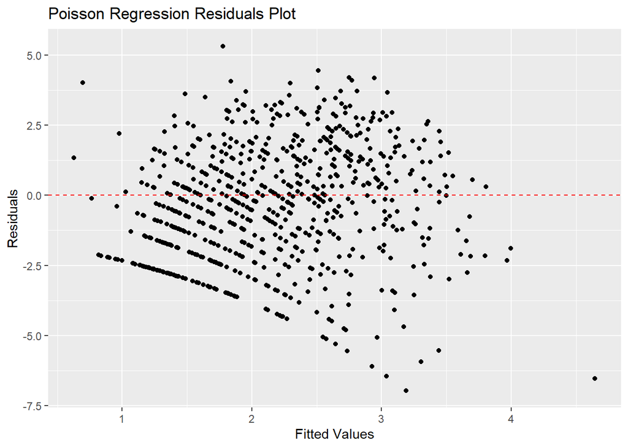

```r
poisson_residuals = data.frame(fitted = predict(poisson_mod_3),
                               residuals = residuals(poisson_mod_3))

library(ggplot2)

ggplot(poisson_residuals, aes(x = fitted, y = residuals))+
  geom_point()+
  geom_hline(yintercept = 0, linetype = "dashed", color = "red") +
  labs(x = "Fitted Values", y = "Residuals", title = "Poisson Regression Residuals Plot")
```

The data from the model is evenly scattered about the zero line indicating equal variance across the predictor variables hence `the data fits homoscedasticity`

there are extreme residuals above `2.5` and below `5`

3. **RMSE**

```r
actual_poisson = data.frame(employ = test$employ, count = rep(1, nrow(test)))
actual_poisson = actual_poisson %>% group_by(employ)%>%summarise(count = sum(count))
actual_poisson
```

```
## # A tibble: 37 × 2
##    employ count
##     <dbl> <dbl>
##  1      0    18
##  2      1     7
##  3      2    14
##  4      3     7
##  5      4     7
##  6      5     4
##  7      6     5
##  8      7     7
##  9      8     6
## 10      9     7
## # ℹ 27 more rows
```

```r
poisson_test = multi_test
predicted_poisson = predict(poisson_mod_3, poisson_test, type ="response")
actual_val_pois = actual_poisson$count
rmse_pois = sqrt(mean(actual_val_pois- predicted_poisson)^2)
real_pois = mean(actual_poisson$count)
cat("The rmse of the poisson model is: ", rmse_pois,"\nThe actual value is: ", real_pois)
```

```
## The rmse of the poisson model is:  7.132109
## The actual value is:  4.918919
```

```r
# propotional difference
tol = 0.1
pois_diff = abs(rmse_pois - real_pois)/ (max(abs(rmse_pois), abs(real_pois)))
pois_diff < tol
```

```
## [1] FALSE
```

the rmse is larger than the actual mean of the counts this means the predicted values are significantly different from the actual data even though the model best fits the data

### 4. Negative binomial

#### a. Data set

Regression analysis used for modeling count data that exhibits overdispersion, which occurs when the variance is greater than the mean in count data.

```r
neg_binom_data = linear_regress_data
neg_binom_test = poisson_test
count_data = c(2, 7, 10)
print_var_mn = function(x){
var_x = var(x)
mn_x = sum(x)/nrow(x)
col_neg_bin = colnames(x)
return(cat("The variance of", col_neg_bin," is: ",var_x,
    "\nAnd, the mean is: ", mn_x))
}
for(i in 1:length(count_data)){
  print(print_var_mn(neg_binom_data[, count_data[i]]))
}
```

```
## The variance of tenure  is:  477.2847
## And, the mean is:  35NULL
## The variance of employ  is:  106.4294
## And, the mean is:  11.05143NULL
## The variance of reside  is:  1.987924
## And, the mean is:  2.281429NULL
```

From this `tenure` and `employ` fit the desired data for negative binomial regression

#### b. fit the model

```r
library(MASS)
neg_bin_mod = glm.nb(employ~., data = neg_binom_data)
summary(neg_bin_mod)
```

```
##
## Call:
## glm.nb(formula = employ ~ ., data = neg_binom_data, init.theta = 2.426020187,
##     link = log)
##
## Coefficients:
##               Estimate Std. Error z value Pr(>|z|)
## (Intercept) -2.471e-01  2.013e-01  -1.228  0.21952
## region2      2.130e-02  7.000e-02   0.304  0.76094
## region3     -5.643e-02  6.946e-02  -0.812  0.41661
## tenure       7.464e-03  2.699e-03   2.765  0.00569 **
## age          4.299e-02  3.392e-03  12.671  < 2e-16 ***
## marital2    -1.503e-01  7.241e-02  -2.076  0.03792 *
## address     -7.587e-03  3.722e-03  -2.038  0.04154 *
## income       2.544e-03  2.968e-04   8.571  < 2e-16 ***
## retire2     -1.128e-01  1.411e-01  -0.800  0.42370
## gender2     -3.278e-02  5.670e-02  -0.578  0.56317
## reside       5.681e-02  2.641e-02   2.151  0.03148 *
## tollfree2    7.266e-02  9.546e-02   0.761  0.44657
## tollten      2.120e-05  5.017e-05   0.423  0.67264
## equipten    -5.311e-05  4.210e-05  -1.262  0.20712
## cardten      1.437e-05  5.422e-05   0.265  0.79100
## wireten      1.621e-05  4.179e-05   0.388  0.69808
## loglong      9.466e-02  6.918e-02   1.368  0.17118
## logcard      9.743e-04  3.808e-02   0.026  0.97959
## custcat2    -1.105e-01  9.473e-02  -1.166  0.24343
## custcat3    -1.226e-02  9.672e-02  -0.127  0.89911
## custcat4     5.695e-02  9.478e-02   0.601  0.54792
## churn2      -1.444e-01  7.184e-02  -2.010  0.04448 *
## ---
## Signif. codes:  0 '***' 0.001 '**' 0.01 '*' 0.05 '.' 0.1 ' ' 1
##
## (Dispersion parameter for Negative Binomial(2.426) family taken to be 1)
##
##     Null deviance: 1576.82  on 699  degrees of freedom
## Residual deviance:  849.35  on 678  degrees of freedom
## AIC: 4393.8
##
## Number of Fisher Scoring iterations: 1
##
##
##               Theta:  2.426
##           Std. Err.:  0.190
##
##  2 x log-likelihood:  -4347.786
```

```r
neg_bin_mod_2 = glm.nb(employ~tenure+age+marital+income+reside, data = neg_binom_data)
summary(neg_bin_mod_2)
```

```
##
## Call:
## glm.nb(formula = employ ~ tenure + age + marital + income + reside,
##     data = neg_binom_data, init.theta = 2.310516501, link = log)
##
## Coefficients:
##               Estimate Std. Error z value Pr(>|z|)
## (Intercept) -0.1984753  0.1281949  -1.548   0.1216
## tenure       0.0096453  0.0015204   6.344 2.24e-10 ***
## age          0.0413083  0.0027381  15.087  < 2e-16 ***
## marital2    -0.1538444  0.0725006  -2.122   0.0338 *
## income       0.0026538  0.0002839   9.348  < 2e-16 ***
## reside       0.0637020  0.0266130   2.394   0.0167 *
## ---
## Signif. codes:  0 '***' 0.001 '**' 0.01 '*' 0.05 '.' 0.1 ' ' 1
##
## (Dispersion parameter for Negative Binomial(2.3105) family taken to be 1)
##
##     Null deviance: 1525.69  on 699  degrees of freedom
## Residual deviance:  844.83  on 694  degrees of freedom
## AIC: 4381.7
##
## Number of Fisher Scoring iterations: 1
##
##
##               Theta:  2.311
##           Std. Err.:  0.177
##
##  2 x log-likelihood:  -4367.665
```

```r
neg_bin_mod_3 = glm.nb(employ~tenure+age+income, data = neg_binom_data)
summary(neg_bin_mod_3)
```

```
##
## Call:
## glm.nb(formula = employ ~ tenure + age + income, data = neg_binom_data,
##     init.theta = 2.28404083, link = log)
##
## Coefficients:
##               Estimate Std. Error z value Pr(>|z|)
## (Intercept) -0.0469284  0.1028731  -0.456    0.648
## tenure       0.0093615  0.0015093   6.203 5.55e-10 ***
## age          0.0396412  0.0026410  15.010  < 2e-16 ***
## income       0.0026694  0.0002848   9.372  < 2e-16 ***
## ---
## Signif. codes:  0 '***' 0.001 '**' 0.01 '*' 0.05 '.' 0.1 ' ' 1
##
## (Dispersion parameter for Negative Binomial(2.284) family taken to be 1)
##
##     Null deviance: 1513.78  on 699  degrees of freedom
## Residual deviance:  845.62  on 696  degrees of freedom
## AIC: 4384.3
##
## Number of Fisher Scoring iterations: 1
##
##
##               Theta:  2.284
##           Std. Err.:  0.175
##
##  2 x log-likelihood:  -4374.271
```

#### c. Accuracy of fit

```r
neg_bin_pred = predict(neg_bin_mod_2, neg_binom_test, type = "response")
act_neg_bin = data.frame(val = neg_binom_test$employ,
                         count = rep(1, nrow(neg_binom_test)))
act_neg_bin = act_neg_bin %>% group_by(val) %>% summarise(count = sum(count))
act_neg =  act_neg_bin$count

rmse_neg_bin = sqrt(mean(act_neg - neg_bin_pred)^2)
mean_neg_bin = mean(act_neg)
cat("The rmse of the negative binom model is:", rmse_neg_bin,"\nThe actual value is:", mean_neg_bin)
```

```
## The rmse of the negative binom model is: 8.642734
## The actual value is: 4.918919
```

```r
tol = 0.1
neg_bin_diff = abs(rmse_neg_bin - mean_neg_bin)/ (max(abs(rmse_neg_bin), abs(mean_neg_bin)))
if(pois_diff < tol){
  print("the rmse is smaller than the actual mean of the counts this means the predicted values are statistically similar to the actual data and the model best fits the data")
}else{
  print("the rmse is larger than the actual mean of the counts this means the predicted values are significantly different from the actual data even though the model best fits the data")
}
```

```
## [1] "the rmse is larger than the actual mean of the counts this means the predicted values are significantly different from the actual data even though the model best fits the data"
```

### 5. quasi-binomial

Introduces a dispersion parameter, similar to the negative binomial model for count data.

Quasi-binomial regression is applied when analyzing binomial data with excessive variability. It’s commonly used in situations where the assumption of equidispersion in the binomial model does not hold.

#### a. Test for the viability of variables

```r
var_ratio = function(x){
  v_ra = var(x)/ mean(x)
  # Check if the variance-to-mean ratio exceeds a certain threshold (e.g., 1)
if (v_ra > 1) {
  out = "The variance-to-mean ratio suggests potential overdispersion, suitable for quasi-binomial regression.\n"
} else {
 out = "The variance-to-mean ratio does not indicate significant overdispersion.\n"
}
return(out)
}
```

```r
quasi_binom_data = linear_regress_data
quasi_binom_test = neg_binom_test
```

```r
# binomial columns
quasi_col = c("retire", "gender", "tollfree", "churn")
for(i in 1:length(quasi_col)){
  print(var_ratio(
    as.numeric(
      as.character(quasi_binom_data[[ quasi_col[i]]])
    )
  ))
}
```

```
## [1] "The variance-to-mean ratio does not indicate significant overdispersion.\n"
## [1] "The variance-to-mean ratio does not indicate significant overdispersion.\n"
## [1] "The variance-to-mean ratio does not indicate significant overdispersion.\n"
## [1] "The variance-to-mean ratio does not indicate significant overdispersion.\n"
```

There is no suitable variable for quasi-binomial data as `the variance-to-mean ratio does not indicate significant overdispersion for any of the variables`

## 6. Non Parametric tests

### 1. sign rank test = one-sample t-test, one-sample z-test

```r
wilkox_train = linear_regress_data
wilkox_test = quasi_binom_test
```

#### a. using Wilcox sign test

```r
wilkox_begin_ind = sample(nrow(wilkox_train), 70, replace = FALSE)
wilkox_begin = wilkox_train[wilkox_begin_ind,]
```

```r
library(dplyr)
wilkox_num = colnames(wilkox_begin %>%
                        select_if(is.numeric))
wilkox_num
```

```
##  [1] "tenure"   "age"      "address"  "income"   "employ"   "reside"
##  [7] "tollten"  "equipten" "cardten"  "wireten"  "loglong"  "logcard"
```

Compares the median of a single sample of paired observations to a hypothetical median (usually 0, assuming no difference).

**Assumption**: The differences between paired observations are symmetrically distributed.

**Z-test**:

- **Purpose**: Tests the difference between a sample mean and a known population mean when the population standard deviation is known

because the sample size is `> 30` so the z-test is chosen

```r
z_t_test = function(samp_mn, pop_mn, pop_sd, samp_size){
  z_score = (samp_mn - pop_mn)/ (pop_sd/ sqrt(samp_size))
  t_score = 2* (1 - pnorm(abs(z_score)))
  out = paste("z-score is: ", z_score)
  out = paste(out,"t-score is: ")
  out = paste(out, t_score)
  return(out)
}
```

```r
wilkox_pop = rbind(quasi_binom_data, quasi_binom_test)
wilkox_pop_cols = wilkox_pop[, colnames(wilkox_pop) %in% wilkox_num]
wilkox_samp_cols = wilkox_begin[, colnames(wilkox_pop) %in% wilkox_num]
wilkox_pop_std = apply(wilkox_pop_cols, 2, sd)
wilkox_samp_mn = apply(wilkox_samp_cols, 2, mean)
wilkox_pop_mn = apply(wilkox_pop_cols, 2, mean)

# find the z and p scores
for(i in 1:length(wilkox_pop_mn)){
  cat("For: ",wilkox_num[i], " values are :\n")
  print(z_t_test(wilkox_samp_mn[i], wilkox_pop_mn[i],wilkox_pop_std[i], 182))
}
```

```
## For:  tenure  values are :
## [1] "z-score is:  1.91483814076485 t-score is:  0.0555131487139768"
## For:  age  values are :
## [1] "z-score is:  -0.404837379531983 t-score is:  0.685597050598578"
## For:  address  values are :
## [1] "z-score is:  0.678649375271418 t-score is:  0.497360049904113"
## For:  income  values are :
## [1] "z-score is:  0.980500026608819 t-score is:  0.326839356505366"
## For:  employ  values are :
## [1] "z-score is:  0.48681198911129 t-score is:  0.626391573317558"
## For:  reside  values are :
## [1] "z-score is:  -2.02498663773421 t-score is:  0.0428687363310678"
## For:  tollten  values are :
## [1] "z-score is:  2.38386588283742 t-score is:  0.0171318447053623"
## For:  equipten  values are :
## [1] "z-score is:  1.87461735115025 t-score is:  0.0608453843968331"
## For:  cardten  values are :
## [1] "z-score is:  0.0370572795250214 t-score is:  0.970439334614129"
## For:  wireten  values are :
## [1] "z-score is:  1.72843327644187 t-score is:  0.083910573857606"
## For:  loglong  values are :
## [1] "z-score is:  2.26689391981462 t-score is:  0.0233967067495411"
## For:  logcard  values are :
## [1] "z-score is:  -2.03698014285756 t-score is:  0.0416520319532463"
```

From these `z-scores` indicate how many standard deviations the data in each column is above `mean`

The `t-score` indicates how close the data is to the `hypothesised` mean. The standard errors from mean.

### 2. wilcoxc sign rank test = paired t-test

#### b. Selecting paired samples

```r
wilkox_after_ind = sample(nrow(wilkox_test), 70, replace = FALSE)
wilkox_after = wilkox_test[wilkox_after_ind,]
```

#### c. select the numeric columns

```r
for(col in wilkox_num){
  wilkox_test = wilcox.test(wilkox_begin[[col]], wilkox_after[[col]], paired = TRUE)
  cat("The wilcox test for ", col, "is: \n")
  print(wilkox_test)
}
```

```
## The wilcox test for  tenure is:
##
##  Wilcoxon signed rank test with continuity correction
##
## data:  wilkox_begin[[col]] and wilkox_after[[col]]
## V = 1121, p-value = 0.4788
## alternative hypothesis: true location shift is not equal to 0
##
## The wilcox test for  age is:
##
##  Wilcoxon signed rank test with continuity correction
##
## data:  wilkox_begin[[col]] and wilkox_after[[col]]
## V = 1085.5, p-value = 0.5949
## alternative hypothesis: true location shift is not equal to 0
##
## The wilcox test for  address is:
##
##  Wilcoxon signed rank test with continuity correction
##
## data:  wilkox_begin[[col]] and wilkox_after[[col]]
## V = 990.5, p-value = 0.3551
## alternative hypothesis: true location shift is not equal to 0
##
## The wilcox test for  income is:
##
##  Wilcoxon signed rank test with continuity correction
##
## data:  wilkox_begin[[col]] and wilkox_after[[col]]
## V = 1190, p-value = 0.7609
## alternative hypothesis: true location shift is not equal to 0
##
## The wilcox test for  employ is:
##
##  Wilcoxon signed rank test with continuity correction
##
## data:  wilkox_begin[[col]] and wilkox_after[[col]]
## V = 934, p-value = 0.3669
## alternative hypothesis: true location shift is not equal to 0
```

```
## The wilcox test for  reside is:
##
##  Wilcoxon signed rank test with continuity correction
##
## data:  wilkox_begin[[col]] and wilkox_after[[col]]
## V = 458.5, p-value = 0.1794
## alternative hypothesis: true location shift is not equal to 0
##
## The wilcox test for  tollten is:
##
##  Wilcoxon signed rank test with continuity correction
##
## data:  wilkox_begin[[col]] and wilkox_after[[col]]
## V = 804, p-value = 0.8612
## alternative hypothesis: true location shift is not equal to 0
```

```
## The wilcox test for  equipten is:
##
##  Wilcoxon signed rank test with continuity correction
##
## data:  wilkox_begin[[col]] and wilkox_after[[col]]
## V = 541, p-value = 0.5954
## alternative hypothesis: true location shift is not equal to 0
##
## The wilcox test for  cardten is:
##
##  Wilcoxon signed rank test with continuity correction
##
## data:  wilkox_begin[[col]] and wilkox_after[[col]]
## V = 870, p-value = 0.02948
## alternative hypothesis: true location shift is not equal to 0
```

```
## The wilcox test for  wireten is:
##
##  Wilcoxon signed rank test with continuity correction
##
## data:  wilkox_begin[[col]] and wilkox_after[[col]]
## V = 491, p-value = 0.9674
## alternative hypothesis: true location shift is not equal to 0
##
## The wilcox test for  loglong is:
##
##  Wilcoxon signed rank test with continuity correction
##
## data:  wilkox_begin[[col]] and wilkox_after[[col]]
## V = 1194, p-value = 0.7788
## alternative hypothesis: true location shift is not equal to 0
##
## The wilcox test for  logcard is:
##
##  Wilcoxon signed rank test with continuity correction
##
## data:  wilkox_begin[[col]] and wilkox_after[[col]]
## V = 566, p-value = 7.619e-05
## alternative hypothesis: true location shift is not equal to 0
```

The wilcox test indicates that the only values with p-values that are significantly smaller than `0.05` are `cardten` and `logcard`

This means that for these values $h_0$ (there difference in the two paired samples of begin and after is not statistically significant) of wilcox sign test is rejected indicating a significant difference in the observatservations of the paired samples.

### 3. mann u test = independent t-test

#### a. ordinal data

Whitney-Wilcoxon test, is a non-parametric statistical test used to determine if there is a significant difference between two independent groups.

When dealing with ordinal or non-normally distributed data.

The Mann-Whitney U test doesn’t assume the data are normally distributed. It assesses whether the distributions of the two groups are different based on their ranks

$h_0$ Assumes no difference between the medians of the two groups

$h_1$ difference between the medians of the two groups

```r
ordi_data = c(6, 7, 3, 2)
col_ordi = colnames(quasi_binom_data[, ordi_data])
col_ordi
```

```
## [1] "income" "employ" "age"    "tenure"
```

#### b. Group reside

reside is taken to mean how many people reside in a household

reside 1 means small house, 0 means large house

```r
mann_u_data = quasi_binom_data
mann_u_data$reside = ifelse(mann_u_data$reside < 4, 1,0) # selecting income for low residence houses
group_1 = subset(mann_u_data, reside == 1)$income # selecting income for high residence houses
group_2 = subset(mann_u_data, reside == 0)$income
```

#### c. Perform the mann-whitney U test

```r
mann_u_test = wilcox.test(group_1, group_2)
mann_u_test
```

```
##
##  Wilcoxon rank sum test with continuity correction
##
## data:  group_1 and group_2
## W = 43656, p-value = 0.04782
## alternative hypothesis: true location shift is not equal to 0
```

The p-value of `0.04782` is less than the threshold of `0.05` which indicates that the null hypothesis should be rejected.

This means that there is a statistically significant difference in the median income of individuals in low residence houses than in high residence house

### 4. Kruskal-wallis H-test = one way ANOVA

A non-parametric statistical test used to determine whether two or more independent groups have different medians.

It’s an extension of the Mann-Whitney U test for more than two groups and serves as a non-parametric alternative to the one-way analysis of variance (ANOVA) when the assumptions of ANOVA, particularly the assumption of normality, are not met.

$h_0$ medians of all groups are equal

$h_1$ at least one groups median differs from the rest

#### a. Test on income based on multiple categories of residences

```r
kruskal_data = quasi_binom_data
kruskal_test = kruskal.test(income~reside, data = kruskal_data)
kruskal_test
```

```
##
##  Kruskal-Wallis rank sum test
##
## data:  income by reside
## Kruskal-Wallis chi-squared = 8.2153, df = 8, p-value = 0.4127
```

#### b. Interpretation

$h_0$ medians across the levels of income at all reside are not statistically different from each other

$h_1$ medians across the levels of income at all reside are statistically different from each other

because the p-value of `0.4127` is `> 0.05` the null hypothesis is not rejected.

This means that the there is not sufficient evidence to conclude significant difference in the median of income across the different residing people in the homes

### 5. Pearson Correlation = spearman rank correlation

Used to assess the relationship between two continuous variables but how they quantify and evaluate this relationship

#### a. Pearson

Assumes a linear relationship between variables and requires both variables to be normally distributed.

Measures the strength and direction of a linear relationship between two continuous variables.

Values range from -1 to 1.

- 1 indicates a perfect positive linear relationship.
- -1 indicates a perfect negative linear relationship.
- 0 indicates no linear relationship.

#### b. Spearman rank correlation

Doesn’t assume linearity or normality and is suitable for ordinal or non-normally distributed data.

Measures the strength and direction of monotonic relationships between variables.

Similar to Pearson, but `it measures the monotonic relationship rather than the linear relationship`. It’s robust against outliers

#### c. Assessment

```r
pearson_spearman = function(x){
  pearson_cor = cor(linear_regress_data$tollten,
                  linear_regress_data[,x], method = "pearson")
  spearman_cor = cor(linear_regress_data$tollten,
                  linear_regress_data[,x], method = "spearman")
  return (cat("the pearson corerelation for ", x, "is ", pearson_cor," and the spearman correlation is: ", spearman_cor, "\n"))
}
```

```r
continuous_data = c("equipten", "cardten", "wireten", "loglong", "logcard")
for (i in 1:length(continuous_data)){
  print(pearson_spearman(continuous_data[i]))
}
```

```
## the pearson corerelation for  equipten is  0.1529775  and the spearman correlation is:  0.008235781
## NULL
## the pearson corerelation for  cardten is  0.4338877  and the spearman correlation is:  0.4262784
## NULL
## the pearson corerelation for  wireten is  0.489231  and the spearman correlation is:  0.4256853
## NULL
## the pearson corerelation for  loglong is  0.4521349  and the spearman correlation is:  0.3027685
## NULL
## the pearson corerelation for  logcard is  0.3734218  and the spearman correlation is:  0.402089
## NULL
```

`cardten`, `wireten` , `logcard` and `loglong` have a strong linear correlation with `tollten` which because the pearson coefficient is significantly close to `0.5`

## 7. Exploratory Analysis

### 1. PCA, Factor Analysis

Dimensionality reduction techniques used in statistics and data analysis, but they have different approaches and applications.

**PCA** Identifies a new set of uncorrelated variables (principal components) that are linear combinations of the original variables. These components are ordered by the amount of variance they explain

The main goal of PCA is to find a new set of variables, called principal components, which are linear combinations of the original variables.

**Factor Analysis** It assumes that observed variables are influenced by a smaller number of unobserved (latent) variables or factors. It explores the relationships between observed variables and factors.

#### a. the libraries

```r
library(psych)
library(FactoMineR, warn.conflicts = FALSE)
library(factoextra, warn.conflicts = FALSE)
```

#### b. Dataset with no na values and numeric

```r
library(dplyr)
pca_data = linear_regress_data
pca_data = pca_data %>% select_if(is.numeric)
data_pca_cor = cor(pca_data)
data_pca_cor
```

```
##               tenure         age     address      income     employ
## tenure    1.00000000  0.49590322  0.53583114  0.26172391  0.5091654
## age       0.49590322  1.00000000  0.64631885  0.32649061  0.6609560
## address   0.53583114  0.64631885  1.00000000  0.21717708  0.4624427
## income    0.26172391  0.32649061  0.21717708  1.00000000  0.5479243
## employ    0.50916537  0.66095598  0.46244269  0.54792434  1.0000000
## reside   -0.05317894 -0.24491780 -0.20363009 -0.07664680 -0.1314139
## tollten   0.49075263  0.30889545  0.30586766  0.24210120  0.3789216
## equipten  0.32613998  0.06524966  0.04278999  0.07886116  0.0418055
## cardten   0.64649580  0.39665388  0.41225329  0.19625660  0.3874824
## wireten   0.34772439  0.13863071  0.13348074  0.16479076  0.1442611
## loglong   0.81840251  0.46362819  0.49817393  0.22217029  0.4746538
## logcard   0.46934578  0.31981346  0.28895637  0.16402529  0.2957082
##                reside     tollten   equipten     cardten      wireten
## tenure   -0.053178945 0.490752626 0.32613998  0.64649580  0.347724385
## age      -0.244917802 0.308895452 0.06524966  0.39665388  0.138630708
## address  -0.203630086 0.305867664 0.04278999  0.41225329  0.133480741
## income   -0.076646796 0.242101199 0.07886116  0.19625660  0.164790762
## employ   -0.131413918 0.378921603 0.04180550  0.38748238  0.144261080
## reside    1.000000000 0.003025267 0.01149808 -0.04373266 -0.003766883
## tollten   0.003025267 1.000000000 0.15297755  0.43388767  0.489230951
## equipten  0.011498077 0.152977546 1.00000000  0.26306650  0.608091244
## cardten  -0.043732660 0.433887673 0.26306650  1.00000000  0.326426676
## wireten  -0.003766883 0.489230951 0.60809124  0.32642668  1.000000000
## loglong  -0.052472113 0.452134862 0.26119689  0.58462510  0.275712082
## logcard  -0.030407440 0.373421822 0.20743860  0.68435696  0.300667667
##              loglong     logcard
## tenure    0.81840251  0.46934578
## age       0.46362819  0.31981346
## address   0.49817393  0.28895637
## income    0.22217029  0.16402529
## employ    0.47465380  0.29570821
## reside   -0.05247211 -0.03040744
## tollten   0.45213486  0.37342182
## equipten  0.26119689  0.20743860
## cardten   0.58462510  0.68435696
## wireten   0.27571208  0.30066767
## loglong   1.00000000  0.45142261
## logcard   0.45142261  1.00000000
```

```r
# perform pca
pca_analysis = prcomp(pca_data,
                      scale = TRUE) # avoid bias
summary(pca_analysis)
```

```
## Importance of components:
##                           PC1    PC2     PC3    PC4     PC5     PC6     PC7
## Standard deviation     2.1916 1.2995 1.04139 1.0022 0.87947 0.84310 0.75388
## Proportion of Variance 0.4002 0.1407 0.09037 0.0837 0.06446 0.05923 0.04736
## Cumulative Proportion  0.4002 0.5410 0.63134 0.7150 0.77950 0.83873 0.88609
##                            PC8     PC9    PC10    PC11    PC12
## Standard deviation     0.64267 0.53825 0.50932 0.48702 0.40934
## Proportion of Variance 0.03442 0.02414 0.02162 0.01977 0.01396
## Cumulative Proportion  0.92051 0.94465 0.96627 0.98604 1.00000
```

#### c. elements of the pca

```r
names(pca_analysis)
```

```
## [1] "sdev"     "rotation" "center"   "scale"    "x"
```

#### d. standard deviation of the components

```r
pca_analysis$sdev
```

```
##  [1] 2.1915562 1.2994707 1.0413906 1.0022229 0.8794690 0.8430986 0.7538833
##  [8] 0.6426698 0.5382484 0.5093177 0.4870238 0.4093396
```

#### e. Eigen vectors of pca

```r
pca_analysis$rotation
```

```
##                  PC1         PC2         PC3          PC4           PC5
## tenure   -0.38915629  0.05519609  0.16540158 -0.009778759  0.2567694242
## age      -0.32056395 -0.34792025 -0.07917796 -0.111276707  0.1645000362
## address  -0.30490411 -0.28548038  0.10762719 -0.202352561  0.3307716131
## income   -0.20299365 -0.20538162 -0.54861393  0.425400155 -0.2568239178
## employ   -0.32011110 -0.32108045 -0.23404467  0.246962894  0.0054724117
## reside    0.06848547  0.27731764  0.27254332  0.770809759  0.3672532637
## tollten  -0.29298782  0.15716630 -0.06474624  0.203992741 -0.1470754072
## equipten -0.16255076  0.51321553 -0.33293638 -0.243277950  0.2587963137
## cardten  -0.34949705  0.13102779  0.31957573 -0.021395358 -0.3033855505
## wireten  -0.22245630  0.49108141 -0.38372550 -0.095760838  0.0003525488
## loglong  -0.36627628  0.02577944  0.22579366 -0.006648348  0.2745831243
## logcard  -0.29394540  0.15855998  0.33069645 -0.001537534 -0.5836868963
##                   PC6         PC7         PC8          PC9         PC10
## tenure   -0.068628673  0.37774847 -0.02090196 -0.008412562 -0.081676046
## age      -0.008261204 -0.44593976  0.35233409  0.102798562  0.129325556
## address   0.122046465 -0.37412029 -0.61725217 -0.009717937  0.032873002
## income   -0.282380972  0.17478766 -0.45238134  0.059318558  0.085330502
## employ   -0.078577884 -0.02791132  0.51746849 -0.146110791 -0.196019815
## reside   -0.093476548 -0.32253467 -0.01650154  0.014209532 -0.003140247
## tollten   0.767628749  0.10432194  0.04534649 -0.051963417  0.464685770
## equipten -0.398187558 -0.07802663  0.10071575 -0.059088060  0.513049119
## cardten  -0.180613387 -0.03648360 -0.07140490 -0.747567567 -0.077824177
## wireten   0.244034304 -0.22329903 -0.05657563  0.077928240 -0.652245736
## loglong  -0.063029382  0.49754937  0.02995104  0.331006569 -0.117777139
## logcard  -0.204257899 -0.25961382  0.01822762  0.532457753  0.072825451
##                 PC11         PC12
## tenure    0.05705553  0.770901519
## age       0.61619700  0.020423528
## address  -0.35020541 -0.062561351
## income    0.20715023 -0.007816061
## employ   -0.58487123 -0.045442822
## reside    0.04177943 -0.010299677
## tollten  -0.02407480 -0.024792728
## equipten -0.16564473 -0.065166131
## cardten   0.16946183 -0.182680686
## wireten   0.09316337 -0.012000068
## loglong   0.10975202 -0.592323204
## logcard  -0.17381310  0.099615583
```

#### f. mean and standard deviation of the original variables

```r
pca_analysis$center # mean
```

```
##     tenure        age    address     income     employ     reside    tollten
##  35.000000  41.867143  11.515714  76.641429  11.051429   2.281429 553.480986
##   equipten    cardten    wireten    loglong    logcard
## 475.295657 596.456537 469.392355   2.186607   2.100037
```

```r
pca_analysis$scale# standard deviation
```

```
##       tenure          age      address       income       employ       reside
##   21.8468463   12.8090770   10.1381605   97.0275612   10.3164624    1.4099374
##      tollten     equipten      cardten      wireten      loglong      logcard
##  932.8068059  895.6784606  819.3304889 1023.9116482    0.7433373    1.2043899
```

#### g. pca scores

```r
pca_analysis$x
```

```
##                  PC1           PC2           PC3          PC4           PC5
##   [1,] -4.2266525031 -2.9449380047  0.0305642341  0.050936331  1.919529e-01
##   [2,]  1.2548364612  0.2526486656  0.5379528649 -0.608669255 -1.207525e+00
##   [3,]  0.8981020284  1.7949720018 -0.1564456425  0.017112650  4.488961e-01
##   [4,] -1.5020934091 -1.4034231795  0.4550506708  0.751548212 -1.145701e-02
##   [5,] -0.1544828212 -0.2143576369 -0.7162292995 -0.703404364  9.873851e-02
##   [6,] -3.7879233451 -1.8279809568  0.5352915189  0.083700798 -5.642617e-01
##   [7,] -3.5823572604  0.6564937576 -0.4033206089  1.204759086  1.904756e-01
##   [8,]  1.4471452816  0.3818742659  0.7798324498  1.537971399  1.452603e+00
##   [9,] -0.7945359859  1.3368030174 -0.1695137303 -0.244619623 -2.008790e+00
##  [10,]  1.5268865211 -0.1024168811  0.4660607311 -1.023247593 -1.208009e+00
##  [11,]  2.2060825623  0.6397419880  0.5164598628  1.002980896  9.802343e-01
##  [12,] -1.3912155162  0.8217115019 -1.5659493983  0.895997624  1.495348e+00
##  [13,]  2.6405321706  1.3673615412  0.2285903905  1.687897247  1.235767e+00
##  [14,] -0.5225043502 -2.0418678266 -1.4560039563  1.154734093 -7.918608e-01
```

[output cut: 2088 more lines]

#### h. Visualization

1. **Scree plot**

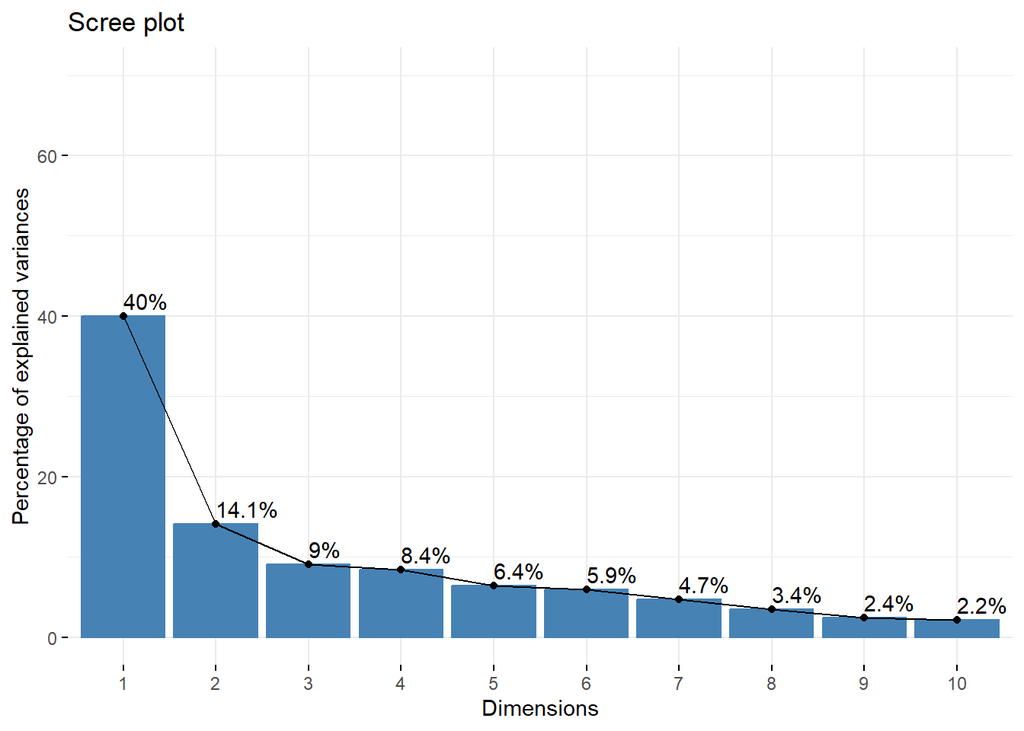

```r
fviz_eig(pca_analysis,
         addlabels = TRUE,
         ylim = c(0, 70))
```

2. **Data point labels**

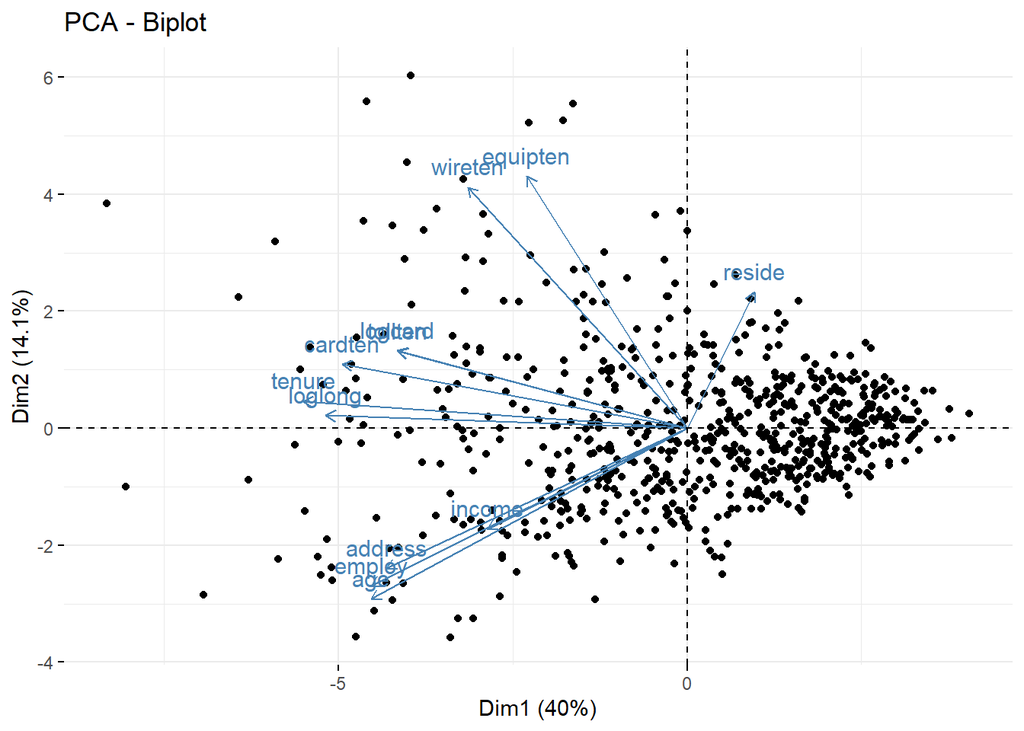

```r
fviz_pca_biplot(pca_analysis,
                label = "var")
```

#### i. Colored groups

color by age 1 young, 0 old

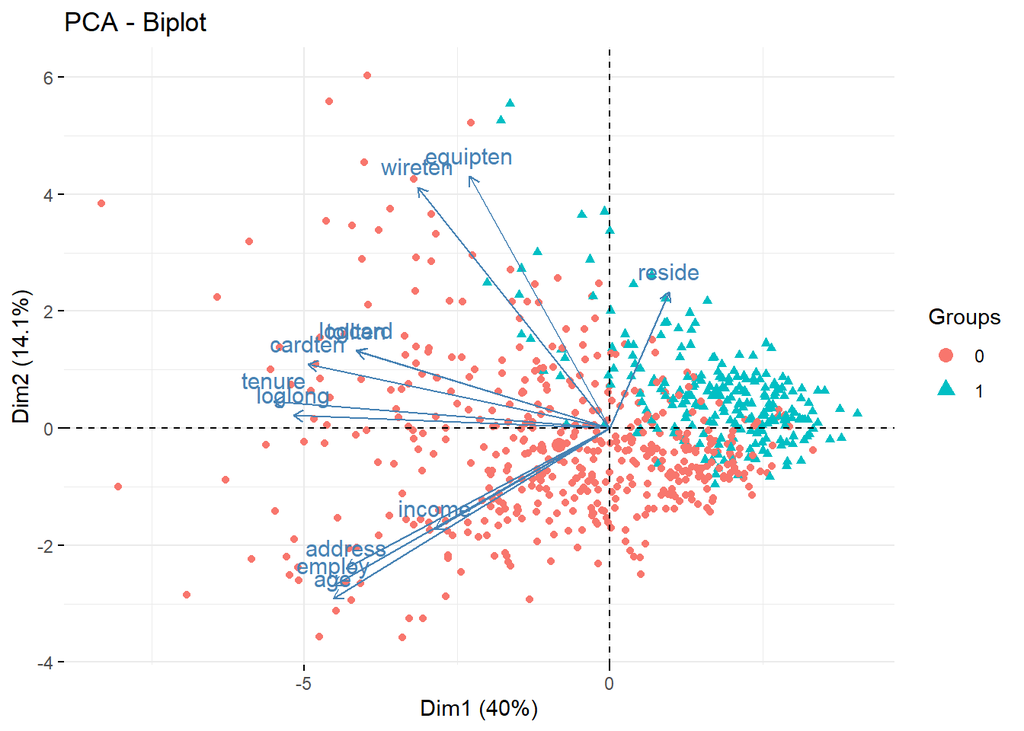

```r
pca_data$age = ifelse(pca_data$age < 35, 1, 0)
fviz_pca_biplot(pca_analysis,
                label = "var",
                habillage = pca_data$age)
```

### 2. Fixed effect and random effect models

**Fixed/ factor effect models** These models consider categorical variables (factors) with a fixed set of levels or categories

```r
factor_data = linear_regress_data
factor_data = factor_data %>% select_if(is.factor)
factor_data$age = linear_regress_data$age
```

```r
fact_eff_mod = lm(age~., factor_data)
summary(fact_eff_mod)
```

```
##
## Call:
## lm(formula = age ~ ., data = factor_data)
##
## Residuals:
##     Min      1Q  Median      3Q     Max
## -42.492  -8.087  -0.862   8.102  31.965
##
## Coefficients:
##             Estimate Std. Error t value Pr(>|t|)
## (Intercept)  41.6394     1.4442  28.831  < 2e-16 ***
## region2       0.8628     1.0487   0.823   0.4109
## region3       0.5432     1.0376   0.524   0.6007
## marital2      0.5007     0.8525   0.587   0.5572
## retire2      23.9962     1.9326  12.417  < 2e-16 ***
## gender2       0.4212     0.8475   0.497   0.6193
## tollfree2     1.4315     1.1371   1.259   0.2085
## custcat2     -1.5651     1.1749  -1.332   0.1833
## custcat3      0.4514     1.4292   0.316   0.7522
## custcat4     -2.7601     1.3565  -2.035   0.0423 *
## churn2       -5.7049     0.9604  -5.940 4.51e-09 ***
## ---
## Signif. codes:  0 '***' 0.001 '**' 0.01 '*' 0.05 '.' 0.1 ' ' 1
##
## Residual standard error: 11.12 on 689 degrees of freedom
## Multiple R-squared:  0.2568, Adjusted R-squared:  0.246
## F-statistic:  23.8 on 10 and 689 DF,  p-value: < 2.2e-16
```

`churn` and `retirement` are the key factors that can help predict a person’s age

**Random effect model** models are used when dealing with categorical variables or factors whose levels are sampled from a larger population.

```r
rem_data = linear_regress_data
rem_data = data.frame(sapply(rem_data[, c(2, 5, 7, 10)], as.factor))
rem_data$age = linear_regress_data$age
```

```r
library(lme4)
rem_mod = lmer(age~(1|tenure ), data = rem_data)
summary(rem_mod)
```

```
## Linear mixed model fit by REML ['lmerMod']
## Formula: age ~ (1 | tenure)
##    Data: rem_data
##
## REML criterion at convergence: 5430.2
##
## Scaled residuals:
##     Min      1Q  Median      3Q     Max
## -3.7233 -0.6966 -0.0568  0.6645  3.0155
##
## Random effects:
##  Groups   Name        Variance Std.Dev.
##  tenure   (Intercept)  39.64    6.296
##  Residual             118.88   10.903
## Number of obs: 700, groups:  tenure, 73
##
## Fixed effects:
##             Estimate Std. Error t value
## (Intercept)  41.8558     0.8573   48.82
```

### 3. assessing missing-ness types:

#### a. MAR

Suggests that the probability of missingness might depend on observed data but not on unobserved data after conditioning on other observed variables.

`mar and mnar` are performed by imputation and assessing the change due to imputation, for the linear regression data imputation causes no change in the spread of the data.

#### **b. CMAR**

It suggests that the missingness may depend on unobserved variables, making it more complex to handle compared to MAR

#### c. MNAR

MNAR implies that the missing values are systematically different from observed values and can introduce bias if not handled properly.

#### d. GEE regression

Useful when the correlation structure within the data needs to be considered, and it provides population-averaged estimates while accounting for within-subject correlation

```r
library(geepack)
# Fit GEE model
gee_model <- geeglm(age ~ ., data = factor_data,id = gender,
                    family =poisson())
summary(gee_model)
```

```
##
## Call:
## geeglm(formula = age ~ ., family = poisson(), data = factor_data,
##     id = gender)
##
##  Coefficients:
##             Estimate  Std.err      Wald Pr(>|W|)
## (Intercept)  3.72729  0.03425 11842.329  < 2e-16 ***
## region2      0.02073  0.02370     0.765   0.3818
## region3      0.01375  0.02330     0.348   0.5551
## marital2     0.01122  0.02100     0.286   0.5931
## retire2      0.44981  0.02105   456.721  < 2e-16 ***
## gender2      0.01060  0.02044     0.269   0.6040
## tollfree2    0.03410  0.02752     1.536   0.2152
## custcat2    -0.03602  0.02769     1.692   0.1934
## custcat3     0.01250  0.03059     0.167   0.6827
## custcat4    -0.06610  0.03220     4.214   0.0401 *
## churn2      -0.14536  0.02165    45.098 1.87e-11 ***
## ---
## Signif. codes:  0 '***' 0.001 '**' 0.01 '*' 0.05 '.' 0.1 ' ' 1
##
## Correlation structure = independence
## Estimated Scale Parameters:
##
##             Estimate Std.err
## (Intercept)    2.977  0.1537
## Number of clusters:   355  Maximum cluster size: 9
```